# Nuclear Energy in the Neighbourhood? Examining Public Support for Small Modular Reactors in the United Kingdom

## Research project description

The United Kingdom faces growing demands on its electricity grid, and electricity prices have become a major cost of living issue. At the same time, the UK has made a commitment to transition away from carbon-emitting sources of energy, and to build small modular reactors (SMRs). How SMRs are described and where they are sited can prompt considerations that lead people to support or oppose them.

This project asks: how supportive is the public of SMRs? Does calling SMRs *reactors* rather than *power stations* (H1), or placing them *in your local area* rather than *in the United Kingdom* (H2) shift support? Does *distance* to existing nuclear sites shape support for SMRs (H3)? Also, do local area framing effects vary across different parts of the UK (RQ1)?

The core of this project is a survey-based experiment (*n* = 1,276). The experimental design was a 2x2 factorial design, where as part of the survey question wording, SMRs were either described as *reactors* or as *power stations*, and were also described as either being in the participant’s *local area* or *in the United Kingdom*.

In addition to these two experimental manipulations, the analysis includes a number of covariates: country (meaning England, Scotland, Wales, and Northern Ireland), basic demographics (sex, age, education), attention to/attitudes toward electricity issues, trust in the electricity industry, trust in government, climate attitudes, left-right political orientations, and proximity to existing nuclear sites.

The main analyses are a set of linear models estimated in a Bayesian statistical framework using `brms` in R. As robustness checks, the same model specifications are estimated with ordinary least squares (frequentist) estimation; they are also estimated using `PyMC` and `statsmodels` in Python.

## Preparing the R session

Set R options and load required packages.

```r
rm(list=ls())
options(scipen=999)
options(width = 160)
select <- dplyr::select
vars <- dplyr::vars
coalesce <- dplyr::coalesce

getwd()

library(tidyverse)
library(haven)
library(survey)
library(brms)
library(cmdstanr)
library(bayesplot)
library(expss)
library(lavaan)
library(weights)
library(semTools)
library(modelsummary)
library(DescTools)
library(broom.mixed)
library(scales)
library(ggh4x)
library(openxlsx)
library(kableExtra)
```

## Data prep

### Read in the survey data

The survey experiment was conducted with the Vox Pop Labs online panel between 7 October and 11 November 2025. The data constitute a non-probability sample, so the supplied weights combine quasi-randomization (using the Annual Population Survey as a reference probability sample) with raking on sex, age, education, country of birth, region and 2024 recalled vote to align each each experimental condition with the characteristics of the UK public.

The respondent-level survey data are publicly accessible from the project’s Github repo as a .csv file, and can be read into R directly:

```r
data.url <- paste0("https://raw.githubusercontent.com/tgravelle/",
                   "nuclear-energy-uk/refs/heads/main/data/UK_SMR.csv")
data.0 <- read_csv(data.url)
rm(data.url)
head(data.0)
```

```
# A tibble: 6 × 67
  ResponseId      date       weight SEX_panel AGE_panel EDU_panel BORN_panel COUNTRY_panel condition RPS   LOC   CONSENT FOLLOW_GOVT   MII LOCAL_ECON LOCAL_ENVT
  <chr>           <date>      <dbl> <chr>     <chr>     <chr>     <chr>      <chr>             <dbl> <chr> <chr>   <dbl>       <dbl> <dbl>      <dbl>      <dbl>
1 R_8Gr1JKlamihP… 2025-10-07  1.82  Female    65-74     Age 70+   Born in UK England               3 Reac… Local       1           1     6          4          3
2 R_2GdZKmNA4vQp… 2025-10-07  0.339 Male      65-74     Age 70+   Born in UK England               2 Powe… UK          1           1     2          4          2
3 R_8FZWSuUVFq1s… 2025-10-07  4.47  Female    65-74     Postgrad… Not born … England               4 Powe… Local       1           1     4          4          1
4 R_8tJSHMrRk5Tw… 2025-10-07  0.226 Male      65-74     Bachelor… Born in UK England               1 Reac… UK          1           1     9          3          3
5 R_2kmOYIPRhcGR… 2025-10-07  0.737 Male      35-44     O-level/… Born in UK England               4 Powe… Local       1           1     4          5          3
6 R_2gFSjpyMt8eH… 2025-10-07  0.154 Male      65-74     Bachelor… Born in UK England               3 Reac… Local       1           1     2          3          2
# ℹ 51 more variables: FOLLOW_ELEC <dbl>, ELECTRICITY_1 <dbl>, ELECTRICITY_2 <dbl>, ELECTRICITY_3 <dbl>, ELECTRICITY_4 <dbl>, CLIMATE_1 <dbl>, CLIMATE_2 <dbl>,
#   CLIMATE_3 <dbl>, CLIMATE_4 <dbl>, CLIMATE_5 <dbl>, TRUST_1 <dbl>, TRUST_2 <dbl>, TRUST_3 <dbl>, TRUST_4 <dbl>, TRUST_5 <dbl>, TRUST_6 <dbl>, TRUST_7 <dbl>,
#   TRUST_8 <dbl>, TRUST_9 <dbl>, TRUST_10 <dbl>, TRUST_11 <dbl>, TRUST_12 <dbl>, TRUST_13 <dbl>, TRUST_14 <dbl>, TRUST_15 <dbl>, TRUST_16 <dbl>,
#   SMNR_UK <dbl>, SMNP_UK <dbl>, SMNR_LOCAL <dbl>, SMNP_LOCAL <dbl>, PID <dbl>, VOTE_INTENT <dbl>, VOTE_LEANING <dbl>, VOTE_2024 <dbl>, LEFT_RIGHT <dbl>,
#   LEAVE_REMAIN <dbl>, IND_SCOTLAND <dbl>, IND_WALES <dbl>, GENDER <dbl>, YEAR_BIRTH <dbl>, EDUCATION <dbl>, BORN <chr>, station_dist_km <dbl>,
#   ln_station_dist_km <dbl>, nuclear_dist_km <dbl>, ln_nuclear_dist_km <dbl>, SEX <chr>, AGE <chr>, AgeYears <dbl>, EDU <chr>, COUNTRY <chr>
```

Next, the data need to be prepared for analysis with some standard `dplyr` data carpentry. This includes reflecting (reversing) the direction of coding of survey items where necessary, recoding missing values, and setting and reordering the levels of categorical variables.

```r
data.1 <- data.0 %>%
  mutate(support_smr = case_when(
    SMNR_UK %in% 1:5 | SMNP_UK %in% 1:5 | SMNR_LOCAL %in% 1:5 | SMNP_LOCAL %in% 1:5
     ~ 6 - coalesce(SMNR_UK, SMNP_UK, SMNR_LOCAL, SMNP_LOCAL),
    SMNR_UK == 6 | SMNP_UK == 6 | SMNR_LOCAL == 6 | SMNP_LOCAL == 6 ~ 3,
    TRUE ~ 3
  )) %>%
  mutate(support_smr_nr = case_when(
    SMNR_UK %in% 1:5 | SMNP_UK %in% 1:5 | SMNR_LOCAL %in% 1:5 | SMNP_LOCAL %in% 1:5
     ~ 6 - coalesce(SMNR_UK, SMNP_UK, SMNR_LOCAL, SMNP_LOCAL),
    SMNR_UK == 6 | SMNP_UK == 6 | SMNR_LOCAL == 6 | SMNP_LOCAL == 6 ~ -9,
    TRUE ~ -9
  )) %>%
  mutate(RPS = fct_relevel(as_factor(RPS), "Power Station", "Reactor")) %>%
  mutate(LOC = fct_relevel(as_factor(LOC), "UK", "Local")) %>%
  mutate(Female = case_when(
    GENDER == 1 ~ 0,
    GENDER == 2 ~ 1,
    SEX_panel == "Male" ~ 0,
    SEX_panel == "Female" ~ 1,
    TRUE ~ 0.5
  )) %>%
  mutate(ln_age_years = log(AgeYears)) %>%
  mutate(ln_age_years = ln_age_years - weighted.mean(x = ln_age_years, w = weight)) %>%
  mutate(ln_nuclear_dist_km = ln_nuclear_dist_km - weighted.mean(x = ln_nuclear_dist_km, w = weight)) %>%
  mutate(ed = as_factor(case_when(
    EDUCATION %in% c(10, 11, 12, 17, 19, -99) ~ "O-level/GCSE/None",
    EDUCATION %in% c(7, 8) ~ "A-level",
    EDUCATION %in% c(3, 4, 5, 6, 9, 13, 14, 15, 16, 18) ~ "HND/HNC/trade",
    EDUCATION == 2 ~ "Bachelor degree",
    EDUCATION == 1 ~ "Postgraduate degree",
    TRUE ~ EDU_panel
  ))) %>%
  mutate(Educ = case_when(
    ed == "O-level/GCSE/None" ~ 0,
    ed == "A-level" ~ 0.25,
    ed == "HND/HNC/trade" ~ 0.5,
    ed == "Bachelor degree" ~ 0.75,
    ed == "Postgraduate degree" ~ 1,
    TRUE ~ 0
  )) %>%
  mutate(Educ = Educ - weighted.mean(x = Educ, w = weight)) %>%
  select(-ed) %>%
  mutate(Country = fct_relevel(COUNTRY, "England", "Wales", "Scotland", "Northern Ireland")) %>%
  mutate(CountryWales = case_when(
    Country == "Wales" ~ 1,
    TRUE ~ 0
  )) %>%
  mutate(CountryNorthernIreland = case_when(
    Country == "Northern Ireland" ~ 1,
    TRUE ~ 0
  )) %>%
  mutate(mii_col = case_when(
    MII == 9 ~ 1,
    TRUE ~ 0
  )) %>%
  mutate(left_right = LEFT_RIGHT) %>%
  mutate(local_econ = 6 - LOCAL_ECON) %>%
  mutate(local_envt = 6 - LOCAL_ENVT) %>%
  mutate(elec_envt_friendly = 6 - ELECTRICITY_1) %>%
  mutate(need_more_elec = 6 - ELECTRICITY_2) %>%
  mutate(elec_self_suff = 6 - ELECTRICITY_3) %>%
  mutate(elec_price_low = 6 - ELECTRICITY_4) %>%
  mutate(cc_problem = 6 - CLIMATE_1) %>%
  mutate(envt_exagg_r = CLIMATE_2) %>%
  mutate(cc_action = 6 - CLIMATE_3) %>%
  mutate(cc_uncert_occ_r = CLIMATE_4) %>%
  mutate(cc_uncert_eff_r = CLIMATE_5) %>%
  mutate(follow_elec = 5 - FOLLOW_ELEC) %>%
  mutate(trust_westminster = 5 - TRUST_1) %>%
  mutate(trust_pm = 5 - TRUST_2) %>%
  mutate(trust_local_mp = 5 - TRUST_3) %>%
  mutate(trust_council = 5 - TRUST_13) %>%
  mutate(trust_elec_cos = 5 - TRUST_14) %>%
  mutate(trust_elec_supp = 5 - TRUST_15) %>%
  mutate(across(c(left_right:cc_uncert_eff_r), ~ case_when(
    .x %in% 1:5 ~ .x,
    TRUE ~ NA_real_
  ))) %>%
  mutate(across(c(follow_elec:trust_elec_supp), ~ case_when(
    .x %in% 1:4 ~ .x,
    TRUE ~ NA_real_
  ))) %>%
  mutate(VOTE2024 = as_factor(case_when(
    VOTE_2024 == 2 ~ "Labour",
    VOTE_2024 == 1 ~ "Conservative",
    VOTE_2024 == 3 ~ "Liberal Democrat",
    VOTE_2024 == 13 ~ "Reform UK",
    VOTE_2024 == 4 ~ "Scottish National Party",
    VOTE_2024 == 6 ~ "Plaid Cymru",
    VOTE_2024 == 10 ~ "Nationalist",
    VOTE_2024 %in% c(8, 11, 12) ~ "Unionist",
    VOTE_2024 == 14 ~ "Other",
    VOTE_2024 %in% c(16, 17, 18, 19, 20) ~ "DNV",
    TRUE ~ "DNV"
  ))) %>%
  mutate(VOTE2024 = fct_relevel(VOTE2024, "Labour", "Conservative", "Liberal Democrat", "Reform UK",
                                "Scottish National Party", "Plaid Cymru", "Nationalist", "Unionist")) %>%
  mutate(Scotland_Local = case_when(
    Country == "Scotland" & LOC == "Local" ~ 1,
    TRUE ~ 0
  )) %>%
  mutate(Scotland_Ind_Ref = as_factor(case_when(
    Country == "Scotland" & IND_SCOTLAND == 1 ~ "Yes",
    Country == "Scotland" ~ "Not yes",
    TRUE ~ "Outside Scotland"
  ))) %>%
  mutate(Scotland_Ind_Ref = fct_relevel(Scotland_Ind_Ref, "Outside Scotland", "Yes", "Not yes")) %>%
  mutate(Scotland_Vote_2024 = as_factor(case_when(
    Country == "Scotland" & VOTE2024 == "Scottish National Party" ~ "Scotland-SNP",
    Country == "Scotland" ~ "Scotland-Other",
    TRUE ~ "Outside Scotland"
  ))) %>%
  mutate(Scotland_Vote_2024 = fct_relevel(Scotland_Vote_2024, "Outside Scotland", "Scotland-SNP", "Scotland-Other")) %>%
  mutate(Scotland_PID = as_factor(case_when(
    Country == "Scotland" & PID == 4 ~ "Scotland-SNP",
    Country == "Scotland" ~ "Scotland-Other",
    TRUE ~ "Outside Scotland"
  ))) %>%
  mutate(Scotland_PID = fct_relevel(Scotland_PID, "Outside Scotland", "Scotland-SNP", "Scotland-Other"))
```

### Check the recoded data

After these data prep steps, it’s important to *inspect the data* by running basic frequency distributions.

```r
xtabs(~ condition, addNA = TRUE, na.action = NULL, data = data.1)
```

```
condition
  1   2   3   4
319 319 319 319
```

```r
xtabs(~ condition + Country, addNA = TRUE, na.action = NULL, data = data.1)
```

```
         Country
condition England Wales Scotland Northern Ireland
        1     275     8       33                3
        2     273    12       29                5
        3     271    17       26                5
        4     275     9       30                5
```

```r
xtabs(~ RPS, addNA = TRUE, na.action = NULL, data = data.1)
```

```
RPS
Power Station       Reactor
          638           638
```

```r
xtabs(~ LOC, addNA = TRUE, na.action = NULL, data = data.1)
```

```
LOC
   UK Local
  638   638
```

```r
xtabs(~ support_smr, addNA = TRUE, na.action = NULL, data = data.1)
```

```
support_smr
  1   2   3   4   5
 65  62 234 334 581
```

```r
xtabs(~ support_smr_nr + Female, addNA = TRUE, data = data.1)
```

```
              Female
support_smr_nr   0   1
            -9  27  29
            1   42  23
            2   40  22
            3  107  71
            4  247  87
            5  499  82
```

```r
xtabs(~ support_smr_nr + Female, addNA = TRUE, data = data.1) %>% prop.table(margin = 2)*100
```

```
              Female
support_smr_nr         0         1
            -9  2.806653  9.235669
            1   4.365904  7.324841
            2   4.158004  7.006369
            3  11.122661 22.611465
            4  25.675676 27.707006
            5  51.871102 26.114650
```

```r
xtabs(~ Female, addNA = TRUE, na.action = NULL, data = data.1)
```

```
Female
  0   1
962 314
```

```r
xtabs(~ Educ, addNA = TRUE, na.action = NULL, data = data.1)
```

```
Educ
-0.467580479550112 -0.217580479550112 0.0324195204498883  0.282419520449888  0.532419520449888
               160                171                351                359                235
```

```r
xtabs(~ Country, addNA = TRUE, na.action = NULL, data = data.1)
```

```
Country
         England            Wales         Scotland Northern Ireland
            1094               46              118               18
```

```r
xtabs(~ Country, addNA = TRUE, na.action = NULL, data = data.1)
```

```
Country
         England            Wales         Scotland Northern Ireland
            1094               46              118               18
```

```r
xtabs(~ CountryWales, addNA = TRUE, na.action = NULL, data = data.1)
```

```
CountryWales
   0    1
1230   46
```

```r
xtabs(~ CountryNorthernIreland, addNA = TRUE, na.action = NULL, data = data.1)
```

```
CountryNorthernIreland
   0    1
1258   18
```

```r
xtabs(~ local_econ, addNA = TRUE, na.action = NULL, data = data.1)
```

```
local_econ
  1   2   3   4   5
368 529 302  69   8
```

```r
xtabs(~ local_envt, addNA = TRUE, na.action = NULL, data = data.1)
```

```
local_envt
   1    2    3    4    5 <NA>
 180  365  439  234   57    1
```

```r
xtabs(~ elec_envt_friendly, addNA = TRUE, na.action = NULL, data = data.1)
```

```
elec_envt_friendly
   1    2    3    4    5 <NA>
 321  231  160  306  254    4
```

```r
xtabs(~ need_more_elec, addNA = TRUE, na.action = NULL, data = data.1)
```

```
need_more_elec
   1    2    3    4    5 <NA>
   4   23  121  397  729    2
```

```r
xtabs(~ elec_self_suff, addNA = TRUE, na.action = NULL, data = data.1)
```

```
elec_self_suff
   1    2    3    4    5 <NA>
   6   26   71  368  799    6
```

```r
xtabs(~ elec_price_low, addNA = TRUE, na.action = NULL, data = data.1)
```

```
elec_price_low
   1    2    3    4    5 <NA>
   6   30  100  301  835    4
```

```r
xtabs(~ cc_problem, addNA = TRUE, na.action = NULL, data = data.1)
```

```
cc_problem
   1    2    3    4    5 <NA>
 163  155  164  275  513    6
```

```r
xtabs(~ envt_exagg_r, addNA = TRUE, na.action = NULL, data = data.1)
```

```
envt_exagg_r
   1    2    3    4    5 <NA>
 270  229  108  210  457    2
```

```r
xtabs(~ cc_action, addNA = TRUE, na.action = NULL, data = data.1)
```

```
cc_action
   1    2    3    4    5 <NA>
 207  183  177  249  455    5
```

```r
xtabs(~ cc_uncert_occ_r, addNA = TRUE, na.action = NULL, data = data.1)
```

```
cc_uncert_occ_r
   1    2    3    4    5 <NA>
 143  187  155  240  547    4
```

```r
xtabs(~ cc_uncert_eff_r, addNA = TRUE, na.action = NULL, data = data.1)
```

```
cc_uncert_eff_r
   1    2    3    4    5 <NA>
 355  416  180  213  109    3
```

```r
xtabs(~ follow_elec, addNA = TRUE, na.action = NULL, data = data.1)
```

```
follow_elec
   1    2    3    4 <NA>
  61  317  625  268    5
```

```r
xtabs(~ trust_westminster, addNA = TRUE, na.action = NULL, data = data.1)
```

```
trust_westminster
   1    2    3    4 <NA>
 622  354  262   36    2
```

```r
xtabs(~ trust_pm, addNA = TRUE, na.action = NULL, data = data.1)
```

```
trust_pm
   1    2    3    4 <NA>
 705  239  270   56    6
```

```r
xtabs(~ trust_local_mp, addNA = TRUE, na.action = NULL, data = data.1)
```

```
trust_local_mp
   1    2    3    4 <NA>
 377  390  418   87    4
```

```r
xtabs(~ trust_council, addNA = TRUE, na.action = NULL, data = data.1)
```

```
trust_council
   1    2    3    4 <NA>
 302  452  476   45    1
```

```r
xtabs(~ trust_elec_cos, addNA = TRUE, na.action = NULL, data = data.1)
```

```
trust_elec_cos
   1    2    3    4 <NA>
 333  494  417   28    4
```

```r
xtabs(~ trust_elec_supp, addNA = TRUE, na.action = NULL, data = data.1)
```

```
trust_elec_supp
   1    2    3    4 <NA>
 217  328  589  141    1
```

```r
xtabs(~ left_right, addNA = TRUE, na.action = NULL, data = data.1)
```

```
left_right
   1    2    3    4    5 <NA>
 113  281  335  385  118   44
```

```r
xtabs(~ left_right, addNA = TRUE, na.action = NULL, data = data.1)
```

```
left_right
   1    2    3    4    5 <NA>
 113  281  335  385  118   44
```

```r
xtabs(~ VOTE2024, addNA = TRUE, na.action = NULL, data = data.1)
```

```
VOTE2024
                 Labour            Conservative        Liberal Democrat               Reform UK Scottish National Party             Plaid Cymru
                    390                     295                     108                     243                      41                       6
            Nationalist                Unionist                     DNV                   Other
                      2                       7                     130                      54
```

```r
xtabs(~ VOTE2024, addNA = TRUE, na.action = NULL, data = data.1, subset = Country == "Scotland")
```

```
VOTE2024
                 Labour            Conservative        Liberal Democrat               Reform UK Scottish National Party             Plaid Cymru
                     24                      20                       3                      13                      40                       0
            Nationalist                Unionist                     DNV                   Other
                      0                       0                      15                       3
```

```r
xtabs(~ Scotland_Ind_Ref, addNA = TRUE, na.action = NULL, data = data.1)
```

```
Scotland_Ind_Ref
Outside Scotland              Yes          Not yes
            1158               53               65
```

```r
xtabs(~ Scotland_Vote_2024, addNA = TRUE, na.action = NULL, data = data.1)
```

```
Scotland_Vote_2024
Outside Scotland     Scotland-SNP   Scotland-Other
            1158               40               78
```

```r
xtabs(~ Scotland_PID, addNA = TRUE, na.action = NULL, data = data.1)
```

```
Scotland_PID
Outside Scotland     Scotland-SNP   Scotland-Other
            1158               33               85
```

## Validate composite measures

Several of the covariates used in the regression models are composite variables comprised of multiple survey items. Validating these composite scores can be approached from multiple angles: inspecting bivariate correlations, reliability analysis (Cronbach’s alpha), and confirmatory factor analysis (CFA). Given that we have weighted survey data, useful functions for this are `weights::wtd.cor`, `survey::svycralpha` and the `sampling.weights` argument in `lavaan::cfa`.

The survey items measuring attitudes toward electricity issues don’t cohere very well as a composite measure (low inter-item correlations, low Cronbach’s alpha). These will be kept as distict measures in the regression modeling.

```r
wtd.cor(x = (select(data.1, need_more_elec, elec_self_suff, elec_price_low)),
        weight = data.1$weight) %>%
  pluck(., "correlation")
```

```
               need_more_elec elec_self_suff elec_price_low
need_more_elec      1.0000000      0.3319652      0.2753814
elec_self_suff      0.3319652      1.0000000      0.2679952
elec_price_low      0.2753814      0.2679952      1.0000000
```

```r
svycralpha(~need_more_elec + elec_self_suff + elec_price_low,
           (svydesign(id = ~1, strata = ~condition, weights = ~weight, data = data.1)), na.rm = TRUE)
```

```
 *alpha*
0.550821
```

But climate attitudes make for a strong composite measure (high inter-item correlations, high Cronbach’s alpha).

```r
wtd.cor(x = (select(data.1, cc_problem, envt_exagg_r, cc_action, cc_uncert_occ_r)),
        weight = data.1$weight) %>%
  pluck(., "correlation")
```

```
                cc_problem envt_exagg_r cc_action cc_uncert_occ_r
cc_problem       1.0000000    0.8277025 0.8796416       0.6633716
envt_exagg_r     0.8277025    1.0000000 0.8363420       0.6871587
cc_action        0.8796416    0.8363420 1.0000000       0.6336492
cc_uncert_occ_r  0.6633716    0.6871587 0.6336492       1.0000000
```

```r
svycralpha(~cc_problem + envt_exagg_r + cc_action + cc_uncert_occ_r,
           (svydesign(id = ~1, strata = ~condition, weights = ~weight, data = data.1)), na.rm = TRUE)
```

```
  *alpha*
0.9246959
```

Trust in government works well as a composite meaure.

```r
wtd.cor(x = (select(data.1, trust_westminster, trust_pm, trust_local_mp, trust_council)),
        weight = data.1$weight) %>%
  pluck(., "correlation")
```

```
                  trust_westminster  trust_pm trust_local_mp trust_council
trust_westminster         1.0000000 0.8356190      0.4391713     0.3416935
trust_pm                  0.8356190 1.0000000      0.4208390     0.3442588
trust_local_mp            0.4391713 0.4208390      1.0000000     0.3954611
trust_council             0.3416935 0.3442588      0.3954611     1.0000000
```

```r
svycralpha(~trust_westminster + trust_pm + trust_local_mp + trust_council,
           (svydesign(id = ~1, strata = ~condition, weights = ~weight, data = data.1)), na.rm = TRUE)
```

```
  *alpha*
0.7750966
```

So does trust in electricity companies.

```r
wtd.cor(x = (select(data.1, trust_elec_cos, trust_elec_supp)),
        weight = data.1$weight) %>%
  pluck(., "correlation")
```

```
                trust_elec_cos trust_elec_supp
trust_elec_cos       1.0000000       0.7599072
trust_elec_supp      0.7599072       1.0000000
```

```r
svycralpha(~trust_elec_cos + trust_elec_supp,
           (svydesign(id = ~1, strata = ~condition, weights = ~weight, data = data.1)), na.rm = TRUE)
```

```
  *alpha*
0.8603408
```

Next, we will look at a CFA model for the three composite measures we plan to use in the regression analysis (trust in government, trust in electricity companies, and climate attitudes). This will be done using the `lavaan` package, which is very flexible, allowing for categorical indicators, weighted data, correlated errors, and fixing factor loadings to equality – all things we want to specify our model in this case.

This gives us a CFA model with excellent fit to the data (based on the CFI, TLI, RMSEA, SRMR model fit statistics) and generally high factor loadings.

```r
cfa_model <-
  '
  trust_govt =~ NA*trust_westminster + trust_pm + trust_local_mp + trust_council
  trust_elec =~ A*trust_elec_supp + B*trust_elec_cos
  climate =~ NA*cc_problem + envt_exagg_r + cc_action + cc_uncert_occ_r
  A == B
  trust_govt ~~ 1*trust_govt
  climate ~~ 1*climate
  trust_local_mp ~~ trust_council
  trust_westminster ~~ trust_pm
  cc_problem ~~ cc_action
'

cfa_fit <- cfa(cfa_model, data = data.1, ordered = TRUE, estimator = "WLSMV", sampling.weights = "weight",
               missing = "pairwise", parameterization = "theta", mimic = "Mplus")
summary(cfa_fit, fit.measures = TRUE, standardized = TRUE)
```

```
lavaan 0.7-3 ended normally after 163 iterations

  Estimator                                       DWLS
  Optimization method                           NLMINB
  Number of model parameters                        50
  Number of equality constraints                     1

  Number of observations                          1276
  Number of missing patterns                        12
  Sampling weights variable                     weight

Model Test User Model:
                                              Standard      Scaled
  Test Statistic                                44.811      84.921
  Degrees of freedom                                30          30
  P-value (Unknown)                                 NA       0.000
  Scaling correction factor                                  0.610
  Shift parameter                                           11.517
    simple second-order correction (WLSMV)

Model Test Baseline Model:

  Test statistic                             57355.815   28494.009
  Degrees of freedom                                45          45
  P-value                                           NA       0.000
  Scaling correction factor                                  2.015

User Model versus Baseline Model:

  Comparative Fit Index (CFI)                    1.000       0.998
  Tucker-Lewis Index (TLI)                       1.000       0.997

  Robust Comparative Fit Index (CFI)                         0.990
  Robust Tucker-Lewis Index (TLI)                            0.986

Root Mean Square Error of Approximation:

  RMSEA                                          0.020       0.038
  90 Percent confidence interval - lower         0.004       0.029
  90 Percent confidence interval - upper         0.031       0.048
```

[output cut: 111 more lines]

```
   .cc_uncert_cc_r    1.000                               1.000    0.344
    trust_elec        5.448    0.519   10.490    0.000    1.000    1.000

Scaling Parameters:
                   Estimate  Std.Err  z-value  P(>|z|)   Std.lv  Std.all
    trust_wstmnstr    0.467                               0.467    1.000
    trust_pm          0.464                               0.464    1.000
    trust_local_mp    0.805                               0.805    1.000
    trust_council     0.868                               0.868    1.000
    trust_elec_spp    0.394                               0.394    1.000
    trust_elec_cos    0.394                               0.394    1.000
    cc_problem        0.347                               0.347    1.000
    envt_exagg_r      0.246                               0.246    1.000
    cc_action         0.386                               0.386    1.000
    cc_uncert_cc_r    0.586                               0.586    1.000
```

## Extract factor scores, rescale composite measures

We can use the CFA model to calculate respondent-level factor scores (to use in the regression models as covariates) using the `lavaan::lavPredict` function. We will want the factor scores (along with the other continous covariates) to be range-standardized (rescaled between 0 and 1) and then mean centred before being entered into the models. This will help with the interpretation of the results: the model intercepts will have a meaningful interpretation, namely the predicted value of the dependent variable when all categorical covariates are set to their reference values, and *all continuous variables are set to their (pre-transformation) means*.

We will also range-standardize the dependent variable and subtract 0.5; this puts it on a -0.5 to +0.5 scale.

A couple of helper functions `range_std` and `range_centre` simplify these variable transformations. Another `wtd_summary` function helps to sanity-check the resulting transformed variables.

```r
range_std <- function(x) {
  x <- (x - min(x, na.rm = TRUE)) / (max(x, na.rm = TRUE) - min(x, na.rm = TRUE))
}

range_centre <- function(x, w = NULL) {
  x <- (x - min(x, na.rm = TRUE)) / (max(x, na.rm = TRUE) - min(x, na.rm = TRUE))
  x <- x - weighted.mean(x, w, na.rm = TRUE)
}

wtd_summary <- function(x, w, na.rm = TRUE, digits = 5) {
  if (na.rm) {
    valid <- !is.na(x) & !is.na(w)
    x <- x[valid]
    w <- w[valid]
  }
  qt <- Hmisc::wtd.quantile(x, w, probs = c(0, .25, .5, .75, 1))
  m <- Hmisc::wtd.mean(x, w)
  out <- c(qt[1:3], Mean = m, qt[4:5])
  names(out) <- c("Min.", "1st Qu.", "Median", "Mean", "3rd Qu.", "Max.")
  round(out, digits)
}

data.2 <- data.1 %>%
  bind_cols(., (lavPredict(object = cfa_fit, type = "lv", method = "EBM", append.data = FALSE) %>%
                  as.data.frame() %>% as_tibble())) %>%
  mutate(support_smr = range_std(x = support_smr) - 0.5) %>%
  mutate(follow_elec = case_when(follow_elec %in% 1:4 ~ follow_elec, TRUE ~ 1)) %>%
  mutate(follow_elec = range_centre(x = follow_elec, w = weight)) %>%
  mutate(need_more_elec = case_when(need_more_elec %in% 1:5 ~ need_more_elec, TRUE ~ 3)) %>%
  mutate(need_more_elec = range_centre(x = need_more_elec, w = weight)) %>%
  mutate(elec_self_suff = case_when(elec_self_suff %in% 1:5 ~ elec_self_suff, TRUE ~ 3)) %>%
  mutate(elec_self_suff = range_centre(x = elec_self_suff, w = weight)) %>%
  mutate(elec_price_low = case_when(elec_price_low %in% 1:5 ~ elec_price_low, TRUE ~ 3)) %>%
  mutate(elec_price_low = range_centre(x = elec_price_low, w = weight)) %>%
  mutate(local_econ = case_when(local_econ %in% 1:5 ~ local_econ, TRUE ~ 3)) %>%
  mutate(local_econ = range_centre(x = local_econ, w = weight)) %>%
  mutate(local_envt = case_when(local_envt %in% 1:5 ~ local_envt, TRUE ~ 3)) %>%
  mutate(local_envt = range_centre(x = local_envt, w = weight)) %>%
  mutate(trust_govt = range_centre(x = trust_govt, w = weight)) %>%
  mutate(trust_elec = range_centre(x = trust_elec, w = weight)) %>%
  mutate(climate = range_centre(x = climate, w = weight)) %>%
  mutate(left_right = case_when(left_right %in% 1:5 ~ left_right, TRUE ~ 3)) %>%
  mutate(left_right = range_centre(x = left_right, w = weight))
```

```r
wtd_summary(data.2$support_smr, data.2$weight)
```

```
    Min.  1st Qu.   Median     Mean  3rd Qu.     Max.
-0.50000  0.00000  0.25000  0.22224  0.50000  0.50000
```

```r
wtd_summary(data.2$ln_age_years, data.2$weight)
```

```
    Min.  1st Qu.   Median     Mean  3rd Qu.     Max.
-0.94139 -0.27642  0.06005  0.00000  0.32712  0.62258
```

```r
wtd_summary(data.2$follow_elec, data.2$weight)
```

```
    Min.  1st Qu.   Median     Mean  3rd Qu.     Max.
-0.56252 -0.22918  0.10415  0.00000  0.10415  0.43748
```

```r
wtd_summary(data.2$need_more_elec, data.2$weight)
```

```
    Min.  1st Qu.   Median     Mean  3rd Qu.     Max.
-0.82978 -0.07978  0.17022  0.00000  0.17022  0.17022
```

```r
wtd_summary(data.2$elec_self_suff, data.2$weight)
```

```
    Min.  1st Qu.   Median     Mean  3rd Qu.     Max.
-0.86633 -0.11633  0.13367  0.00000  0.13367  0.13367
```

```r
wtd_summary(data.2$elec_price_low, data.2$weight)
```

```
    Min.  1st Qu.   Median     Mean  3rd Qu.     Max.
-0.86116 -0.11116  0.13884  0.00000  0.13884  0.13884
```

```r
wtd_summary(data.2$local_econ, data.2$weight)
```

```
    Min.  1st Qu.   Median     Mean  3rd Qu.     Max.
-0.27014 -0.27014 -0.02014  0.00000  0.22986  0.72986
```

```r
wtd_summary(data.2$local_envt, data.2$weight)
```

```
   Min. 1st Qu.  Median    Mean 3rd Qu.    Max.
-0.4073 -0.1573  0.0927  0.0000  0.0927  0.5927
```

```r
wtd_summary(data.2$trust_govt, data.2$weight)
```

```
    Min.  1st Qu.   Median     Mean  3rd Qu.     Max.
-0.44237 -0.13782 -0.00600  0.00000  0.11690  0.55763
```

```r
wtd_summary(data.2$trust_elec, data.2$weight)
```

```
    Min.  1st Qu.   Median     Mean  3rd Qu.     Max.
-0.37440 -0.18117  0.02555  0.00000  0.19820  0.62560
```

```r
wtd_summary(data.2$climate, data.2$weight)
```

```
    Min.  1st Qu.   Median     Mean  3rd Qu.     Max.
-0.47612 -0.15251  0.00198  0.00000  0.18444  0.51702
```

```r
wtd_summary(data.2$left_right, data.2$weight)
```

```
    Min.  1st Qu.   Median     Mean  3rd Qu.     Max.
-0.47687 -0.22687  0.02313  0.00000  0.27313  0.52313
```

```r
wtd_summary(data.2$ln_nuclear_dist_km, data.2$weight)
```

```
    Min.  1st Qu.   Median     Mean  3rd Qu.     Max.
-3.09948 -0.31031  0.11057  0.00000  0.38889  1.98729
```

## Bayesian regression models

Now we’re finally ready to run some models! The setup for the Bayesian models requires us to specify some priors. Covariate priors are weakly informative. The effects of *reactor* and *local* experimental treatments get small negative priors (mean −0.0625, SD 0.05), reflecting H1, H2 and prior experiments showing lower support for nearby plants.

```r
mean_y <- weighted.mean(x = data.2$support_smr, weights = data.2$weight, na.rm = TRUE)
sd_y <- sqrt(Hmisc::wtd.var(data.2$support_smr, weights = data.2$weight, na.rm = TRUE))
range_age <- max(data.2$ln_age_years) - min(data.2$ln_age_years)
range_dist <- max(data.2$ln_nuclear_dist_km) - min(data.2$ln_nuclear_dist_km)

priors <- c(set_prior(sprintf("normal(%f, %f)", mean_y, sd_y), class = "Intercept"),
            set_prior(sprintf("normal(0, %f)", 0.5 * sd_y), class = "b"),
            set_prior(sprintf("exponential(%f)", 1 / sd_y), class = "sigma"),
            set_prior(sprintf("normal(0, %f)", (0.5 * sd_y) / range_age), class = "b", coef = "ln_age_years"),
            set_prior(sprintf("normal(0, %f)", (0.5 * sd_y) / range_dist), class = "b", coef = "ln_nuclear_dist_km"),
            set_prior("normal(-0.0625, 0.05)", class = "b", coef = "RPSReactor"),
            set_prior("normal(-0.0625, 0.05)", class = "b", coef = "LOCLocal"))
```

The models are estimated using the `brms::brm` function, which calls Stan from within R. The model options specify 5 chains, 2,000 warmup iterations, and 10,000 post-warmup iterations for each chain (so 50,000 post-warmup iterations overall). `cmdstanr` is used as the model back-end, as the default `rstan` back-end is quite a bit slower

### Baseline model

For a baseline model (`m0`), we include the *reactor*/*power station* and *local*/*United Kingdom* along with country, demographics, and distance to the nearest nuclear site as covariates.

```r
m0 <- brm(formula = support_smr | weights(weight) ~ Country + Female + ln_age_years + Educ
          + RPS + LOC + ln_nuclear_dist_km,
          data = data.2,
          family = gaussian,
          prior = priors,
          backend = "cmdstanr",
          chains = 5,
          cores = 5,
          threads = 3,
          iter = 12000,
          warmup = 2000,
          refresh = 1000,
          seed = 20261008,
          save_pars = save_pars(all = TRUE))
m0 <- add_criterion(m0, "loo")
```

This shows small negative effects of the *reactor* and *local* treatments on support for SMRs, as expected. Support is also appreciably lower in Scotland compated to England. We also see that support tends to increase as distance to a nuclear site increases – or conversely, support decreases with proximity to a nuclear site, suggesting a “NIMBY” dynamic.

```r
print(m0, digits = 3)
```

```
 Family: gaussian
  Links: mu = identity
Formula: support_smr | weights(weight) ~ Country + Female + ln_age_years + Educ + RPS + LOC + ln_nuclear_dist_km
   Data: data.2 (Number of observations: 1276)
  Draws: 5 chains, each with iter = 12000; warmup = 2000; thin = 1;
         total post-warmup draws = 50000

Regression Coefficients:
                       Estimate Est.Error l-95% CI u-95% CI  Rhat Bulk_ESS Tail_ESS
Intercept                 0.331     0.015    0.300    0.361 1.000    84692    39995
CountryWales              0.013     0.035   -0.055    0.081 1.000    99904    36611
CountryScotland          -0.119     0.027   -0.172   -0.067 1.000    95520    39126
CountryNorthernIreland    0.038     0.046   -0.052    0.128 1.000    89718    39189
Female                   -0.110     0.016   -0.141   -0.079 1.000    74285    41962
ln_age_years              0.043     0.019    0.007    0.080 1.000    82247    40583
Educ                     -0.018     0.022   -0.061    0.024 1.000    92457    39653
RPSReactor               -0.047     0.015   -0.076   -0.017 1.000   103413    37674
LOCLocal                 -0.044     0.015   -0.072   -0.015 1.000   100338    34858
ln_nuclear_dist_km        0.027     0.012    0.004    0.050 1.000    93067    39213

Further Distributional Parameters:
      Estimate Est.Error l-95% CI u-95% CI  Rhat Bulk_ESS Tail_ESS
sigma    0.276     0.006    0.266    0.288 1.000   101165    38016

Draws were sampled using sample(hmc). For each parameter, Bulk_ESS
and Tail_ESS are effective sample size measures, and Rhat is the potential
scale reduction factor on split chains (at convergence, Rhat = 1).
```

### Adding more covariates

We add the full set of covariates in `m1`.

```r
m1 <- brm(formula = support_smr | weights(weight) ~ Country + Female + ln_age_years + Educ
          + RPS + LOC + ln_nuclear_dist_km
          + follow_elec + need_more_elec + elec_self_suff + elec_price_low + trust_govt + trust_elec + climate + left_right,
          data = data.2,
          family = gaussian,
          prior = priors,
          backend = "cmdstanr",
          chains = 5,
          cores = 5,
          threads = 3,
          iter = 12000,
          warmup = 2000,
          refresh = 1000,
          seed = 20261008,
          save_pars = save_pars(all = TRUE))
m1 <- add_criterion(m1, "loo")
```

Not surprisingly, following news about electricity, agreeing that the UK needs to produce a lot more electricity, trust in electricity companies, climate attitudes, and left-right ideological orientations all shape attitudes toward SMRs. Their inclusion in the model also reduces the estimated effect of the *reactor* treatment, suggesting that there is some attitudinal imbalance across the experimental arms.

```r
print(m1, digits = 3)
```

```
 Family: gaussian
  Links: mu = identity
Formula: support_smr | weights(weight) ~ Country + Female + ln_age_years + Educ + RPS + LOC + ln_nuclear_dist_km + follow_elec + need_more_elec + elec_self_suff + elec_price_low + trust_govt + trust_elec + climate + left_right
   Data: data.2 (Number of observations: 1276)
  Draws: 5 chains, each with iter = 12000; warmup = 2000; thin = 1;
         total post-warmup draws = 50000

Regression Coefficients:
                       Estimate Est.Error l-95% CI u-95% CI  Rhat Bulk_ESS Tail_ESS
Intercept                 0.288     0.014    0.260    0.316 1.000    56099    41451
CountryWales              0.015     0.032   -0.047    0.078 1.000    63267    40658
CountryScotland          -0.114     0.025   -0.162   -0.065 1.000    61524    40292
CountryNorthernIreland    0.031     0.042   -0.053    0.114 1.000    64341    40077
Female                   -0.046     0.015   -0.076   -0.017 1.000    50604    40624
ln_age_years             -0.083     0.019   -0.120   -0.046 1.000    53139    39774
Educ                      0.012     0.021   -0.028    0.053 1.000    61850    41196
RPSReactor               -0.026     0.014   -0.053    0.001 1.000    62549    38856
LOCLocal                 -0.042     0.014   -0.069   -0.016 1.000    62905    39020
ln_nuclear_dist_km        0.028     0.011    0.006    0.049 1.000    64138    38813
follow_elec               0.153     0.028    0.099    0.207 1.000    57342    38887
need_more_elec            0.277     0.038    0.203    0.350 1.000    58439    40634
elec_self_suff           -0.015     0.040   -0.093    0.063 1.000    58511    40883
elec_price_low            0.026     0.036   -0.045    0.097 1.000    62133    41016
trust_govt                0.060     0.056   -0.050    0.168 1.000    42623    39567
trust_elec                0.107     0.036    0.036    0.177 1.000    49837    41339
climate                  -0.148     0.056   -0.258   -0.037 1.000    40302    36661
left_right                0.196     0.033    0.132    0.261 1.000    53481    40191

Further Distributional Parameters:
      Estimate Est.Error l-95% CI u-95% CI  Rhat Bulk_ESS Tail_ESS
sigma    0.252     0.005    0.243    0.262 1.000    65140    38864

Draws were sampled using sample(hmc). For each parameter, Bulk_ESS
and Tail_ESS are effective sample size measures, and Rhat is the potential
scale reduction factor on split chains (at convergence, Rhat = 1).
```

```r
posterior_m1 <- as_draws_df(m1)
mean(posterior_m1$b_RPSReactor >= 0)
```

```
[1] 0.0282
```

```r
mean(posterior_m1$b_RPSReactor < 0)
```

```
[1] 0.9718
```

```r
mean(posterior_m1$b_LOCLocal >= 0)
```

```
[1] 0.00088
```

```r
mean(posterior_m1$b_LOCLocal < 0)
```

```
[1] 0.99912
```

### Interacting the *local* vs. *UK* treatment and country

We can test for heterogeneous treatment effects by including a `LOC*Country` interaction in `m2`.

```r
m2 <- brm(formula = support_smr | weights(weight) ~ Country + Female + ln_age_years + Educ
          + RPS + LOC + ln_nuclear_dist_km
          + follow_elec + need_more_elec + elec_self_suff + elec_price_low + trust_govt + trust_elec + climate + left_right
          + LOC*Country,
          data = data.2,
          family = gaussian,
          prior = priors,
          backend = "cmdstanr",
          chains = 5,
          cores = 5,
          threads = 3,
          iter = 12000,
          warmup = 2000,
          refresh = 1000,
          seed = 20261008,
          save_pars = save_pars(all = TRUE))
m2 <- add_criterion(m2, "loo")
```

This yields an interesting finding: most of the reduced support in Scotland is due to the *local* treatment. There is no evidence of a different *local* effect in Wales or Northern Ireland.

```r
print(m2, digits = 3)
```

```
 Family: gaussian
  Links: mu = identity
Formula: support_smr | weights(weight) ~ Country + Female + ln_age_years + Educ + RPS + LOC + ln_nuclear_dist_km + follow_elec + need_more_elec + elec_self_suff + elec_price_low + trust_govt + trust_elec + climate + left_right + LOC * Country
   Data: data.2 (Number of observations: 1276)
  Draws: 5 chains, each with iter = 12000; warmup = 2000; thin = 1;
         total post-warmup draws = 50000

Regression Coefficients:
                                Estimate Est.Error l-95% CI u-95% CI  Rhat Bulk_ESS Tail_ESS
Intercept                          0.281     0.015    0.253    0.310 1.000    60217    41020
CountryWales                       0.032     0.042   -0.051    0.115 1.000    54799    40699
CountryScotland                   -0.045     0.033   -0.110    0.021 1.000    54113    39776
CountryNorthernIreland             0.017     0.053   -0.086    0.120 1.000    56043    39685
Female                            -0.045     0.015   -0.075   -0.016 1.000    56112    40648
ln_age_years                      -0.081     0.019   -0.118   -0.044 1.000    62843    41302
Educ                               0.011     0.021   -0.029    0.052 1.000    70713    40745
RPSReactor                        -0.026     0.014   -0.053    0.001 1.000    71103    37669
LOCLocal                          -0.030     0.015   -0.058   -0.001 1.000    63239    40588
ln_nuclear_dist_km                 0.026     0.011    0.005    0.048 1.000    70244    39512
follow_elec                        0.153     0.028    0.099    0.208 1.000    62773    37599
need_more_elec                     0.280     0.038    0.206    0.353 1.000    67105    39451
elec_self_suff                    -0.017     0.040   -0.096    0.062 1.000    67022    39814
elec_price_low                     0.024     0.036   -0.048    0.094 1.000    69707    40521
trust_govt                         0.060     0.055   -0.050    0.167 1.000    51036    40144
trust_elec                         0.103     0.036    0.032    0.174 1.000    60376    41479
climate                           -0.147     0.056   -0.257   -0.037 1.000    49392    38853
left_right                         0.193     0.033    0.128    0.257 1.000    61434    39777
CountryWales:LOCLocal             -0.038     0.058   -0.152    0.075 1.000    54732    39613
CountryScotland:LOCLocal          -0.141     0.046   -0.231   -0.052 1.000    52400    38254
CountryNorthernIreland:LOCLocal    0.037     0.072   -0.104    0.179 1.000    55788    39660

Further Distributional Parameters:
      Estimate Est.Error l-95% CI u-95% CI  Rhat Bulk_ESS Tail_ESS
sigma    0.251     0.005    0.242    0.261 1.000    71016    37981

Draws were sampled using sample(hmc). For each parameter, Bulk_ESS
and Tail_ESS are effective sample size measures, and Rhat is the potential
scale reduction factor on split chains (at convergence, Rhat = 1).
```

```r
bayes_factor(m2, m1)
```

```
Recompiling the model with 'rstan'
```

```
Recompilation done
```

```
Iteration: 1
Iteration: 2
Iteration: 3
Iteration: 4
Iteration: 5
```

```
Recompiling the model with 'rstan'
Recompilation done
```

```
Iteration: 1
Iteration: 2
Iteration: 3
Iteration: 4
```

```
Estimated Bayes factor in favor of m2 over m1: 10.14268
```

```r
loo_compare(m1, m2)
```

```
 model elpd_diff se_diff p_worse       diag_diff diag_elpd
    m2       0.0     0.0      NA
    m1      -1.1     4.7    0.59 |elpd_diff| < 4
```

```
Diagnostic flags present.
See ?`loo-glossary` (sections `diag_diff` and `diag_elpd`)
or https://mc-stan.org/loo/reference/loo-glossary.html.
```

```r
posterior_m2 <- as_draws_df(m2)
mean(posterior_m2$b_LOCLocal < 0)
```

```
[1] 0.97936
```

### The *local* vs. *UK* treatment in Scotland vs. the rest of the UK

Given that it is only the `CountryScotland:LOCLocal` higher-order interaction term that is appreciably different from zero, we can respecify the model to have a common slope for `LOCLocal` for England, Wales, and Northern Ireland and a different slope in Scotland in `m3`. This is done by replacing the `LOC*Country` term with `Scotland_Local`.

```r
m3 <- brm(formula = support_smr | weights(weight) ~ Country + Female + ln_age_years + Educ
          + RPS + LOC + ln_nuclear_dist_km
          + follow_elec + need_more_elec + elec_self_suff + elec_price_low + trust_govt + trust_elec + climate + left_right
          + Scotland_Local,
          data = data.2,
          family = gaussian,
          prior = priors,
          backend = "cmdstanr",
          chains = 5,
          cores = 5,
          threads = 3,
          iter = 12000,
          warmup = 2000,
          refresh = 1000,
          seed = 20261008,
          save_pars = save_pars(all = TRUE))
m3 <- add_criterion(m3, "loo")
```

The results from `m3` reconfirm what we saw with `m2`: the negative response in Scotland to the *local* treatment is appreciably larger than in the rest of the UK.

```r
print(m3, digits = 3)
```

```
 Family: gaussian
  Links: mu = identity
Formula: support_smr | weights(weight) ~ Country + Female + ln_age_years + Educ + RPS + LOC + ln_nuclear_dist_km + follow_elec + need_more_elec + elec_self_suff + elec_price_low + trust_govt + trust_elec + climate + left_right + Scotland_Local
   Data: data.2 (Number of observations: 1276)
  Draws: 5 chains, each with iter = 12000; warmup = 2000; thin = 1;
         total post-warmup draws = 50000

Regression Coefficients:
                       Estimate Est.Error l-95% CI u-95% CI  Rhat Bulk_ESS Tail_ESS
Intercept                 0.282     0.015    0.253    0.310 1.000    64511    40155
CountryWales              0.014     0.032   -0.049    0.077 1.000    69976    38044
CountryScotland          -0.045     0.033   -0.111    0.020 1.000    55597    38292
CountryNorthernIreland    0.033     0.042   -0.049    0.116 1.000    70180    38712
Female                   -0.045     0.015   -0.074   -0.015 1.000    60736    41532
ln_age_years             -0.082     0.019   -0.119   -0.045 1.000    64072    42642
Educ                      0.012     0.021   -0.028    0.053 1.000    63802    36899
RPSReactor               -0.026     0.014   -0.053    0.001 1.000    72561    38540
LOCLocal                 -0.031     0.014   -0.059   -0.003 1.000    70108    38392
ln_nuclear_dist_km        0.026     0.011    0.004    0.048 1.000    69069    39211
follow_elec               0.153     0.027    0.099    0.206 1.000    68297    40646
need_more_elec            0.280     0.038    0.206    0.354 1.000    66512    38645
elec_self_suff           -0.014     0.040   -0.092    0.064 1.000    64272    41024
elec_price_low            0.022     0.036   -0.049    0.093 1.000    63882    39872
trust_govt                0.061     0.055   -0.047    0.168 1.000    53623    41024
trust_elec                0.103     0.036    0.033    0.174 1.000    59020    41894
climate                  -0.147     0.056   -0.257   -0.038 1.000    52774    38627
left_right                0.194     0.032    0.130    0.258 1.000    60504    41007
Scotland_Local           -0.140     0.046   -0.229   -0.050 1.000    56240    40745

Further Distributional Parameters:
      Estimate Est.Error l-95% CI u-95% CI  Rhat Bulk_ESS Tail_ESS
sigma    0.251     0.005    0.242    0.261 1.000    71054    37954

Draws were sampled using sample(hmc). For each parameter, Bulk_ESS
and Tail_ESS are effective sample size measures, and Rhat is the potential
scale reduction factor on split chains (at convergence, Rhat = 1).
```

```r
bayes_factor(m3, m1)
```

```
Recompiling the model with 'rstan'
```

```
Recompilation done
```

```
Iteration: 1
Iteration: 2
Iteration: 3
Iteration: 4
```

```
Recompiling the model with 'rstan'
Recompilation done
```

```
Iteration: 1
Iteration: 2
Iteration: 3
Iteration: 4
```

```
Estimated Bayes factor in favor of m3 over m1: 34.66780
```

```r
loo_compare(m1, m3)
```

```
 model elpd_diff se_diff p_worse       diag_diff diag_elpd
    m3       0.0     0.0      NA
    m1      -3.3     4.6    0.76 |elpd_diff| < 4
```

```
Diagnostic flags present.
See ?`loo-glossary` (sections `diag_diff` and `diag_elpd`)
or https://mc-stan.org/loo/reference/loo-glossary.html.
```

```r
posterior_m3 <- as_draws_df(m3)
posterior_m3$b_LOCLocal_plus_Scotland_Local <- posterior_m3$b_LOCLocal + posterior_m3$b_Scotland_Local
mean(posterior_m3$b_Scotland_Local >= 0)
```

```
[1] 0.00096
```

```r
mean(posterior_m3$b_Scotland_Local < 0)
```

```
[1] 0.99904
```

```r
mean(posterior_m3$b_LOCLocal + posterior_m3$b_Scotland_Local < 0)
```

```
[1] 0.99998
```

## Data visualizations

A convenient, compact way of summarizing a set of regression models is to display them graphically in a *coefficient plot*. This depicts both the estimated effects as well as their credibility intervals.

```r
coef.ci.m1 <- m1 %>%
  broom.mixed::tidy(., conf.int = TRUE) %>%
  filter(effect == "fixed") %>%
  bind_rows(., tribble(~term, "England (ref.)", "Power station frame (ref.)", "UK frame (ref.)")) %>%
  mutate(model.name = "Model 1") %>%
  mutate(reference = case_when(
    is.na(estimate) == TRUE ~ "Baseline category",
    TRUE ~ "Non-baseline category"
  )) %>%
  mutate(estimate = case_when(
    reference == "Baseline category" ~ 0,
    TRUE ~ estimate
  )) %>%
  mutate(std.error = case_when(
    TRUE ~ std.error
  )) %>%
  mutate(UCL = case_when(
    reference == "Baseline category" ~ 0,
    TRUE ~ conf.high
  )) %>%
  mutate(LCL = case_when(
    reference == "Baseline category" ~ 0,
    TRUE ~ conf.low
  )) %>%
  select(model.name, term, estimate, LCL, UCL, reference)

coef.ci.m2 <- m2 %>%
  broom.mixed::tidy(., conf.int = TRUE) %>%
  filter(effect == "fixed") %>%
  bind_rows(., tribble(~term, "England (ref.)", "Power station frame (ref.)", "UK frame (ref.)")) %>%
  mutate(model.name = "Model 2") %>%
  mutate(reference = case_when(
    is.na(estimate) == TRUE ~ "Baseline category",
    TRUE ~ "Non-baseline category"
  )) %>%
  mutate(estimate = case_when(
    reference == "Baseline category" ~ 0,
    TRUE ~ estimate
  )) %>%
  mutate(std.error = case_when(
    TRUE ~ std.error
  )) %>%
  mutate(UCL = case_when(
    reference == "Baseline category" ~ 0,
    TRUE ~ conf.high
  )) %>%
  mutate(LCL = case_when(
    reference == "Baseline category" ~ 0,
    TRUE ~ conf.low
  )) %>%
  select(model.name, term, estimate, LCL, UCL, reference)

coef.ci.m3 <- m3 %>%
  broom.mixed::tidy(., conf.int = TRUE) %>%
  filter(effect == "fixed") %>%
  bind_rows(., tribble(~term, "England (ref.)", "Power station frame (ref.)", "UK frame (ref.)")) %>%
  mutate(model.name = "Model 3") %>%
  mutate(reference = case_when(
    is.na(estimate) == TRUE ~ "Baseline category",
    TRUE ~ "Non-baseline category"
  )) %>%
  mutate(estimate = case_when(
    reference == "Baseline category" ~ 0,
    TRUE ~ estimate
  )) %>%
  mutate(std.error = case_when(
    TRUE ~ std.error
  )) %>%
  mutate(UCL = case_when(
    reference == "Baseline category" ~ 0,
    TRUE ~ conf.high
  )) %>%
  mutate(LCL = case_when(
    reference == "Baseline category" ~ 0,
    TRUE ~ conf.low
  )) %>%
  select(model.name, term, estimate, LCL, UCL, reference)

coef.ci.support <- bind_rows(coef.ci.m1, coef.ci.m2, coef.ci.m3) %>%
  mutate(model.name = as_factor(model.name)) %>%
  mutate(model.name = fct_relevel(model.name, "Model 3", "Model 2", "Model 1")) %>%
  mutate(coef.label = as_factor(case_when(
    term == "(Intercept)" ~ "Intercept",
    term == "ln_age_years" ~ "Age (years logged)",
    term == "Educ" ~ "Education",
    term == "CountryWales" ~ "Wales",
    term == "CountryScotland" ~ "Scotland",
    term == "CountryNorthernIreland" ~ "N. Ireland",
    term == "RPSReactor" ~ "Reactor frame",
    term == "LOCLocal" ~ "Local area frame",
    term == "ln_nuclear_dist_km" ~ "Distance to nuclear site\n(km logged)",
    term == "follow_elec" ~ "Follow news about\nelectricity in UK",
    term == "need_more_elec" ~ "Need to produce a lot\nmore electricity",
    term == "elec_self_suff" ~ "UK should be self-sufficient\nin electricity",
    term == "elec_price_low" ~ "Critical to keep price of\nelectricity in UK low",
    term == "trust_govt" ~ "Trust in government",
    term == "trust_elec" ~ "Trust in electricity industry",
    term == "climate" ~ "Climate concern",
    term == "left_right" ~ "Ideology (left-right)",
    term == "CountryWales:LOCLocal" ~ paste0("Wales ", "\u00D7", " Local area frame"),
    term %in% c("CountryScotland:LOCLocal", "Scotland_Local") ~ paste0("Scotland ", "\u00D7", " Local area frame"),
    term == "CountryNorthernIreland:LOCLocal" ~ paste0("N. Ireland ", "\u00D7", " Local area frame"),
    TRUE ~ term
  ))) %>%
  filter(is.na(coef.label) == FALSE) %>%
  mutate(coef.label = fct_relevel(coef.label,
                                  "Intercept",
                                  "Power station frame (ref.)", "Reactor frame",
                                  "UK frame (ref.)", "Local area frame",
                                  "England (ref.)", "Scotland", "Wales", "N. Ireland",
                                  "Distance to nuclear site\n(km logged)",
                                  "Female", "Age (years logged)", "Education",
                                  "Follow news about\nelectricity in UK", "Need to produce a lot\nmore electricity",
                                  "UK should be self-sufficient\nin electricity", "Critical to keep price of\nelectricity in UK low",
                                  "Climate concern", "Trust in government", "Trust in electricity industry",
                                  "Ideology (left-right)",
                                  "Scotland × Local area frame",
                                  "Wales × Local area frame",
                                  "N. Ireland × Local area frame"
  )) %>%
  mutate(pt.shape = case_when(
    model.name == "Model 1" & reference == "Baseline category" ~ 21,
    model.name == "Model 1" ~ 16,
    model.name == "Model 2" & reference == "Baseline category" ~ 22,
    model.name == "Model 2" ~ 15,
    model.name == "Model 3" & reference == "Baseline category" ~ 23,
    model.name == "Model 3" ~ 18
  )) %>%
  mutate(pt.fill = case_when(
    reference == "Baseline category" ~ "white"
  )) %>%
  mutate(pt.size = case_when(
    model.name == "Model 3" & reference == "Baseline category" ~ 0.45,
    model.name == "Model 1" ~ 0.5,
    model.name == "Model 2" ~ 0.5,
    model.name == "Model 3" ~ 0.65
  ))
```

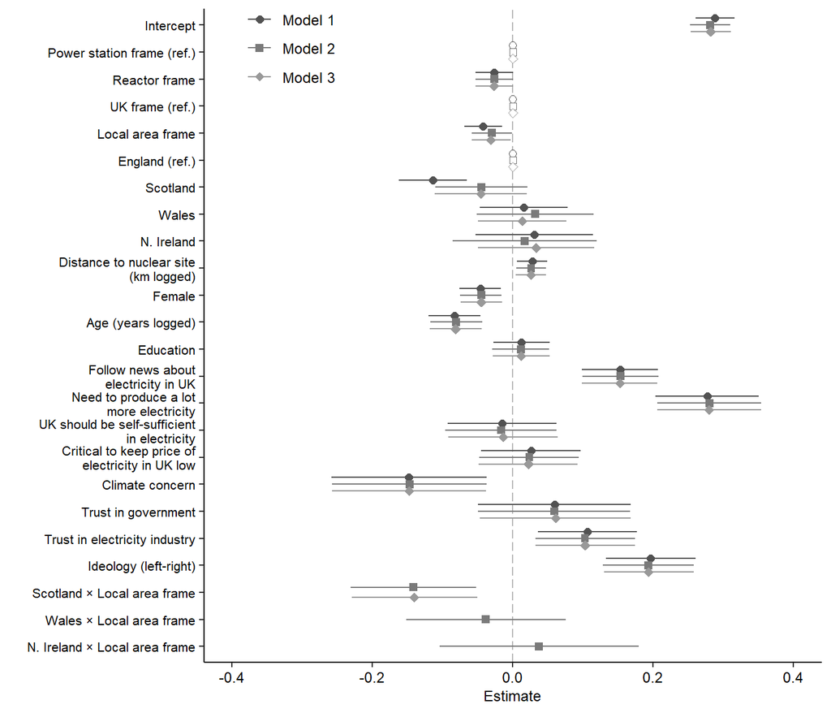

Coefficient plot

```r
ggplot(data = coef.ci.support, aes(x = estimate, y = coef.label, colour = model.name)) +
  geom_vline(xintercept = 0, colour = "grey72", linewidth = 0.5, linetype = "longdash") +
  geom_pointrange(aes(x = estimate, y = coef.label, xmin = LCL, xmax = UCL, colour = model.name),
                  shape = coef.ci.support$pt.shape, size = coef.ci.support$pt.size,
                  fill = coef.ci.support$pt.fill, stroke = 0.4,
                  position = position_dodge(0.75)) +
  scale_color_manual(values = c("grey60", "grey48", "grey32")) +
  labs(x = "Estimate", y = "") +
  scale_y_discrete(limits = rev(levels(coef.ci.support$coef.label))) +
  coord_cartesian(xlim = c(-0.4, 0.4)) +
  scale_x_continuous(breaks = seq(-0.4, 0.4, by = 0.2)) +
  guides(colour = guide_legend(override.aes = list(shape = c(16,15,18), size = c(0.5,0.5,0.6)), reverse = TRUE)) +
  theme(panel.grid.major = element_blank(), panel.grid.minor = element_blank(),
        panel.background = element_blank(), axis.line = element_line(colour = "black"),
        axis.text.x = element_text(size = 9, colour = "black"),
        axis.text.y = element_text(size = 8, colour = "black"),
        text = element_text(size = 9, colour = "black"),
        legend.title = element_blank(),
        legend.position = c(0.14, 0.94),
        legend.text = element_text(size = 9, colour = "black"))
```

We can also translate the results into predicted values of the dependent variable, looking at one experimental treatment at a time. Here, this shows that the *reactor* versus *power station* framing has only a very slight effect on support for SMRs. Support is favourable in all four nations regardless of *reactor* or *power station* terminology.

```r
score_reactor <- c("England", "Scotland", "Wales", "Northern Ireland") %>%
  as_tibble() %>%
  mutate(Country = as_factor(value)) %>%
  select(-value) %>%
  crossing(as_tibble(c("Power Station", "Reactor"))) %>%
  mutate(RPS = as_factor(value)) %>%
  select(-value) %>%
  mutate(Female = 1,
         ln_age_years = 0,
         Educ = 0,
         LOC = "UK",
         ln_nuclear_dist_km = 0,
         follow_elec = 0,
         need_more_elec = 0,
         elec_self_suff = 0,
         elec_price_low = 0,
         trust_govt = 0,
         trust_elec = 0,
         climate = 0,
         left_right = 0,
         Scotland_Local = 0)

pred.country.reactor <- fitted(m3, score_reactor, probs = c(0.085, 0.915), cores = 12) %>%
  as_tibble() %>%
  bind_cols(., score_reactor) %>%
  rename(LCL = Q8.5,
         UCL = Q91.5) %>%
  mutate(Country = fct_relevel(Country, "England", "Scotland", "Wales", "Northern Ireland")) %>%
  select(Country, RPS, Estimate, Est.Error, LCL, UCL)
print(pred.country.reactor, digits = 3)
```

```
# A tibble: 8 × 6
  Country          RPS           Estimate Est.Error   LCL   UCL
  <fct>            <fct>            <dbl>     <dbl> <dbl> <dbl>
1 England          Power Station    0.237    0.0147 0.217 0.257
2 England          Reactor          0.211    0.0149 0.190 0.231
3 Scotland         Power Station    0.192    0.0333 0.146 0.238
4 Scotland         Reactor          0.166    0.0333 0.120 0.211
5 Wales            Power Station    0.251    0.0332 0.206 0.297
6 Wales            Reactor          0.225    0.0332 0.179 0.270
7 Northern Ireland Power Station    0.270    0.0438 0.210 0.330
8 Northern Ireland Reactor          0.244    0.0439 0.184 0.304
```

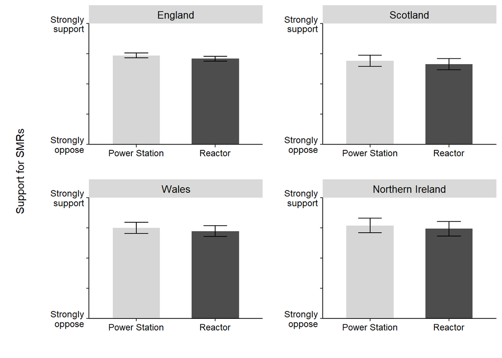

Effect plot: reactor vs. power station frame, by country

```r
ggplot(data = pred.country.reactor, aes(x = RPS, y = Estimate, fill = RPS)) +
  geom_bar(aes(y = Estimate+0.5), stat = "identity", width = 0.6, position = position_dodge(0.75)) +
  scale_fill_manual(values = c("Power Station" = "grey84", "Reactor" = "grey30")) +
  geom_errorbar(aes(ymin = LCL+0.5, ymax = UCL+0.5),
                position = position_dodge(0.75), width = 0.3, colour = "black", linewidth = 0.4) +
  labs(y = "Support for SMRs",
       x = "") +
  coord_cartesian(ylim = c(0, 1)) +
  scale_y_continuous(breaks = seq(0, 1, by = 0.25), expand = c(0,0),
                     labels = c("Strongly\noppose", "", "", "", "Strongly\nsupport")) +
  facet_wrap(~ Country, ncol = 2, axes = "all", scales = "fixed") +
  theme(panel.grid.major = element_blank(), panel.grid.minor = element_blank(),
        panel.background = element_blank(), axis.line = element_line(colour = "black"),
        panel.spacing = unit(1.5, "lines"),
        axis.text = element_text(size = 9, colour = "black"),
        axis.title.y = element_text(margin = margin(t = 0, r = 25, b = 0, l = 10), color = "black"),
        axis.title.x = element_text(margin = margin(t = 10, r = 0, b = 0, l = 0)),
        strip.text.x = element_text(size = 10, colour = "black"),
        legend.position = "none")
```

Also, th *local* versus *United Kingdom* framing has only a modest effect on support for SMRs in England, Wales, and Northern Ireland, but the effect of *local* framing is substantively large in Scotland. This points to a heterogeneous treatment effect.

```r
score_uk_local <- c("England", "Scotland", "Wales", "Northern Ireland") %>%
  as_tibble() %>%
  mutate(Country = as_factor(value)) %>%
  select(-value) %>%
  crossing(as_tibble(c("UK", "Local"))) %>%
  mutate(LOC = as_factor(value)) %>%
  select(-value) %>%
  mutate(Female = 1,
         ln_age_years = 0,
         Educ = 0,
         RPS = "Power Station",
         ln_nuclear_dist_km = 0,
         follow_elec = 0,
         need_more_elec = 0,
         elec_self_suff = 0,
         elec_price_low = 0,
         trust_govt = 0,
         trust_elec = 0,
         climate = 0,
         left_right = 0) %>%
  mutate(Scotland_Local = case_when(
    Country == "Scotland" & LOC == "Local" ~ 1,
    TRUE ~ 0))

pred.country.local <- fitted(m3, score_uk_local, probs = c(0.085, 0.915), cores = 12) %>%
  as_tibble() %>%
  bind_cols(., score_uk_local) %>%
  rename(LCL = Q8.5,
         UCL = Q91.5) %>%
  mutate(Country = fct_relevel(Country, "England", "Scotland", "Wales", "Northern Ireland")) %>%
  mutate(LOC = as_factor(case_when(
    LOC == "UK" ~ "UK",
    LOC == "Local" ~ "Local area"
  ))) %>%
  mutate(LOC = fct_relevel(LOC, "UK", "Local area")) %>%
  select(Country, LOC, Estimate, Est.Error, LCL, UCL)
print(pred.country.local, digits = 3)
```

```
# A tibble: 8 × 6
  Country          LOC        Estimate Est.Error     LCL    UCL
  <fct>            <fct>         <dbl>     <dbl>   <dbl>  <dbl>
1 England          Local area   0.206     0.0146  0.186  0.226
2 England          UK           0.237     0.0147  0.217  0.257
3 Scotland         Local area   0.0207    0.0338 -0.0257 0.0672
4 Scotland         UK           0.192     0.0333  0.146  0.238
5 Wales            Local area   0.220     0.0331  0.175  0.266
6 Wales            UK           0.251     0.0332  0.206  0.297
7 Northern Ireland Local area   0.240     0.0438  0.179  0.300
8 Northern Ireland UK           0.270     0.0438  0.210  0.330
```

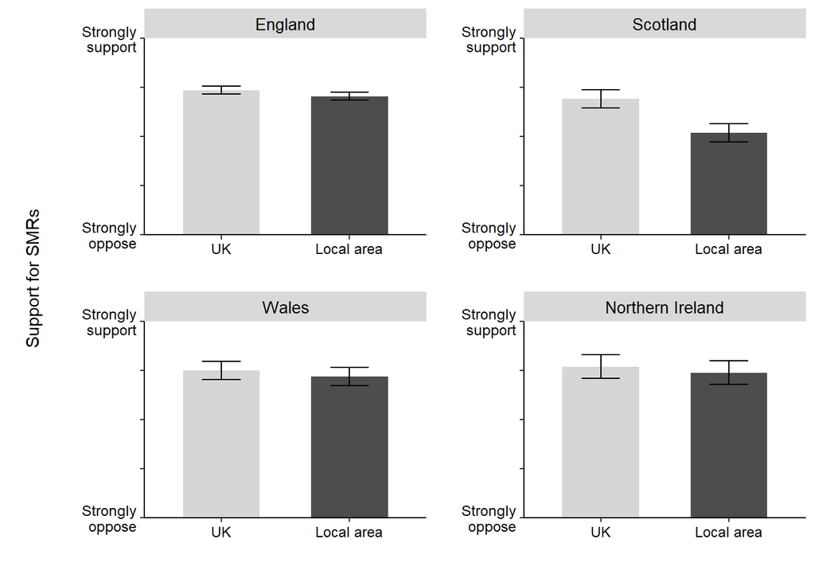

Effect plot: local vs. UK frame, by country

```r
ggplot(data = pred.country.local, aes(x = LOC, y = Estimate, fill = LOC)) +
  geom_bar(aes(y = Estimate+0.5), stat = "identity", width = 0.6, position = position_dodge(0.75)) +
  scale_fill_manual(values = c("UK" = "grey84", "Local area" = "grey30")) +
  geom_errorbar(aes(ymin = LCL+0.5, ymax = UCL+0.5), position = position_dodge(0.75), width = 0.3, colour = "black", linewidth = 0.4) +
  labs(y = "Support for SMRs",
       x = "") +
  coord_cartesian(ylim = c(0, 1)) +
  scale_y_continuous(breaks = seq(0, 1, by = 0.25), expand = c(0,0),
                     labels = c("Strongly\noppose", "", "", "", "Strongly\nsupport")) +
  facet_wrap(~ Country, ncol = 2, axes = "all", scales = "fixed") +
  theme(panel.grid.major = element_blank(), panel.grid.minor = element_blank(),
        panel.background = element_blank(), axis.line = element_line(colour = "black"),
        panel.spacing = unit(1.5, "lines"),
        axis.text = element_text(size = 9, colour = "black"),
        axis.title.y = element_text(margin = margin(t = 0, r = 25, b = 0, l = 10), color = "black"),
        axis.title.x = element_text(margin = margin(t = 10, r = 0, b = 0, l = 0)),
        strip.text.x = element_text(size = 10, colour = "black"),
        legend.position = "none")
```

Given that the data include continuous distance (in kilometres logged) to the nearest nuclear site, we can depict this relationship effectively with a logged X-axis. The rug shows few respondents within a few kilometres, so any effect of close proximity should be seen as tentative.

```r
score_dist <- as_tibble(seq(from = 0.1, to = 20, by = 0.1)) %>%
  bind_rows(as_tibble(seq(from = 21, to = 600, by = 1))) %>%
  rename(nuclear_dist_km = value) %>%
  mutate(ln_nuclear_dist_km = log(nuclear_dist_km) - weighted.mean(x = data.0$ln_nuclear_dist_km, w = data.0$weight)) %>%
  crossing(as_tibble(c("UK", "Local"))) %>%
  mutate(LOC = as_factor(value)) %>%
  select(-value) %>%
  crossing(as_tibble(c("England", "Scotland"))) %>%
  mutate(Country = as_factor(value)) %>%
  select(-value) %>%
  mutate(Female = 1,
         ln_age_years = 0,
         Educ = 0,
         RPS = "Power Station",
         follow_elec = 0,
         need_more_elec = 0,
         elec_self_suff = 0,
         elec_price_low = 0,
         trust_govt = 0,
         trust_elec = 0,
         climate = 0,
         left_right = 0) %>%
  mutate(Scotland_Local = case_when(
    Country == "Scotland" & LOC == "Local" ~ 1,
    TRUE ~ 0
  ))

pred.country.dist.uk.local <- fitted(m3, score_dist, probs = c(0.085, 0.915), cores = 12) %>%
  as_tibble() %>%
  bind_cols(., score_dist) %>%
  rename(LCL = Q8.5,
         UCL = Q91.5) %>%
  mutate(Country = fct_relevel(as_factor(Country), "England", "Scotland")) %>%
  mutate(UK_Local = as_factor(case_when(
    LOC == "UK" ~ "UK",
    LOC == "Local" ~ "Local area"
  ))) %>%
  mutate(UK_Local = fct_relevel(UK_Local, "UK", "Local area")) %>%
  mutate(Country_UK_Local = str_c(Country, "–", UK_Local, " frame")) %>%
  mutate(Country_UK_Local = fct_relevel(Country_UK_Local, "England–UK frame", "England–Local area frame",
                                        "Scotland–UK frame","Scotland–Local area frame")) %>%
  arrange(Country_UK_Local, nuclear_dist_km)

pred.country.dist.uk.local %>%
  filter(UK_Local == "Local area" & nuclear_dist_km %in% c(10, 50, 100, 200)) %>%
  select(Country, nuclear_dist_km, Estimate, Est.Error, LCL, UCL)
```

```
# A tibble: 8 × 6
  Country  nuclear_dist_km Estimate Est.Error      LCL    UCL
  <fct>              <dbl>    <dbl>     <dbl>    <dbl>  <dbl>
1 England               10   0.155     0.0262  0.119   0.191
2 England               50   0.197     0.0151  0.176   0.218
3 England              100   0.215     0.0150  0.194   0.236
4 England              200   0.233     0.0183  0.208   0.258
5 Scotland              10  -0.0306    0.0403 -0.0858  0.0246
6 Scotland              50   0.0114    0.0341 -0.0355  0.0583
7 Scotland             100   0.0294    0.0340 -0.0175  0.0760
8 Scotland             200   0.0475    0.0356 -0.00143 0.0960
```

```r
data.rug <- data.2 %>%
  filter(Country %in% c("England", "Scotland")) %>%
  mutate(UK_Local = as_factor(case_when(
    LOC == "UK" ~ "UK",
    LOC == "Local" ~ "Local area"
  ))) %>%
  mutate(Country_UK_Local = str_c(Country, "–", UK_Local, " frame")) %>%
  mutate(Country_UK_Local = fct_relevel(Country_UK_Local, "England–UK frame", "England–Local area frame",
                                        "Scotland–UK frame","Scotland–Local area frame")) %>%
  select(ResponseId, Country, UK_Local, Country_UK_Local, nuclear_dist_km)
```

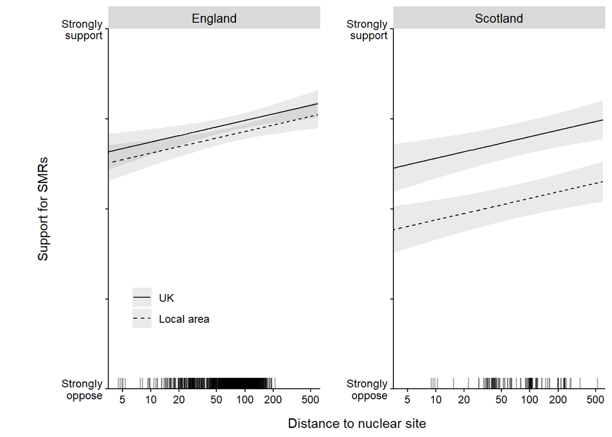

Effect plot: distance to nuclear site, by country

```r
ggplot(data = pred.country.dist.uk.local, aes(y = Estimate+0.5, x = nuclear_dist_km, linetype = UK_Local)) +
  geom_line(aes(y = Estimate+0.5), linewidth = 0.5) +
  geom_ribbon(aes(ymin = LCL+0.5, ymax = UCL+0.5), alpha = 0.1) +
  geom_rug(data = data.rug, aes(x = nuclear_dist_km), sides = "b", alpha = 0.4, linewidth = 0.4, inherit.aes = FALSE) +
  labs(y = "Support for SMRs",
       x = "Distance to nuclear site") +
  coord_cartesian(xlim = c(4.5, 500), ylim = c(0, 1)) +
  scale_x_continuous(trans = "log", breaks = c(5, 10, 20, 50, 100, 200, 500), labels = label_number()) +
  scale_linetype_manual(values = c("UK" = "solid", "Local area" = "dashed")) +
  scale_y_continuous(breaks = seq(0, 1, by = 0.25), expand = c(0,0),
                     labels = c("Strongly\noppose", "", "", "", "Strongly\nsupport")) +
  facet_wrap(~ Country, ncol = 2, axes = "all", scales = "fixed") +
  theme(panel.grid.major = element_blank(), panel.grid.minor = element_blank(),
        panel.background = element_blank(),
        panel.spacing = unit(1.5, "lines"),
        axis.text = element_text(size = 9, colour = "black"),
        axis.line = element_line(colour = "black"),
        axis.ticks = element_line(colour = "black"),
        axis.title.y = element_text(margin = margin(t = 0, r = 10, b = 0, l = 25), color = "black"),
        axis.title.x = element_text(margin = margin(t = 10, r = 0, b = 0, l = 0)),
        strip.text.x = element_text(size = 10, colour = "black"),
        axis.line.x.top = element_line(color = "black"),
        axis.ticks.x.top = element_line(color = "black"),
        axis.text.x.top = element_text(color = "black"),
        legend.title = element_blank(),
        legend.position = c(0.125, 0.225),
        legend.text = element_text(size = 9, colour = "black"))
```

## Robustness check 1: frequentist models using `stats::lm`

Running conventional (frequentist) OLS models using `stats::lm` gives us substantively the same results as the Bayesian models.

```r
m0b <- lm(support_smr ~ Country + Female + ln_age_years + Educ
          + RPS + LOC + ln_nuclear_dist_km,
          data = data.2, weights = weight)
tidy(m0b)
```

```
# A tibble: 10 × 5
   term                    estimate std.error statistic  p.value
   <chr>                      <dbl>     <dbl>     <dbl>    <dbl>
 1 (Intercept)               0.330     0.0157    21.0   5.76e-84
 2 CountryWales              0.0168    0.0360     0.466 6.41e- 1
 3 CountryScotland          -0.124     0.0275    -4.51  7.15e- 6
 4 CountryNorthern Ireland   0.0369    0.0485     0.761 4.47e- 1
 5 Female                   -0.111     0.0158    -7.02  3.71e-12
 6 ln_age_years              0.0453    0.0190     2.39  1.69e- 2
 7 Educ                     -0.0170    0.0220    -0.772 4.40e- 1
 8 RPSReactor               -0.0447    0.0155    -2.89  3.93e- 3
 9 LOCLocal                 -0.0417    0.0155    -2.70  7.08e- 3
10 ln_nuclear_dist_km        0.0338    0.0133     2.55  1.09e- 2
```

```r
m1b <- lm(support_smr ~ Country + Female + ln_age_years + Educ
          + RPS + LOC + ln_nuclear_dist_km
          + follow_elec + need_more_elec + elec_self_suff + elec_price_low + trust_govt + trust_elec + climate + left_right,
          data = data.2, weights = weight)
tidy(m1b)
```

```
# A tibble: 18 × 5
   term                    estimate std.error statistic  p.value
   <chr>                      <dbl>     <dbl>     <dbl>    <dbl>
 1 (Intercept)               0.284     0.0147    19.3   9.16e-73
 2 CountryWales              0.0193    0.0331     0.584 5.60e- 1
 3 CountryScotland          -0.117     0.0254    -4.60  4.66e- 6
 4 CountryNorthern Ireland   0.0290    0.0446     0.650 5.16e- 1
 5 Female                   -0.0431    0.0153    -2.82  4.93e- 3
 6 ln_age_years             -0.0909    0.0195    -4.66  3.44e- 6
 7 Educ                      0.0140    0.0209     0.668 5.04e- 1
 8 RPSReactor               -0.0224    0.0143    -1.57  1.17e- 1
 9 LOCLocal                 -0.0409    0.0142    -2.88  4.02e- 3
10 ln_nuclear_dist_km        0.0337    0.0122     2.76  5.80e- 3
11 follow_elec               0.158     0.0284     5.57  3.17e- 8
12 need_more_elec            0.295     0.0393     7.49  1.28e-13
13 elec_self_suff           -0.0182    0.0419    -0.435 6.64e- 1
14 elec_price_low            0.0242    0.0376     0.644 5.20e- 1
15 trust_govt                0.0814    0.0631     1.29  1.97e- 1
16 trust_elec                0.107     0.0386     2.77  5.73e- 3
17 climate                  -0.170     0.0641    -2.65  8.10e- 3
18 left_right                0.199     0.0344     5.80  8.56e- 9
```

```r
m2b <- lm(support_smr ~ Country + Female + ln_age_years + Educ
          + RPS + LOC + ln_nuclear_dist_km
          + follow_elec + need_more_elec + elec_self_suff + elec_price_low + trust_govt + trust_elec + climate + left_right
          + LOC*Country,
          data = data.2, weights = weight)
print(tidy(m2b), n = 50)
```

```
# A tibble: 21 × 5
   term                             estimate std.error statistic  p.value
   <chr>                               <dbl>     <dbl>     <dbl>    <dbl>
 1 (Intercept)                        0.276     0.0150    18.3   1.12e-66
 2 CountryWales                       0.0442    0.0463     0.955 3.40e- 1
 3 CountryScotland                   -0.0378    0.0355    -1.06  2.88e- 1
 4 CountryNorthern Ireland            0.0104    0.0607     0.171 8.64e- 1
 5 Female                            -0.0423    0.0153    -2.77  5.74e- 3
 6 ln_age_years                      -0.0881    0.0195    -4.53  6.51e- 6
 7 Educ                               0.0124    0.0209     0.592 5.54e- 1
 8 RPSReactor                        -0.0222    0.0142    -1.56  1.19e- 1
 9 LOCLocal                          -0.0252    0.0156    -1.62  1.06e- 1
10 ln_nuclear_dist_km                 0.0318    0.0122     2.61  9.14e- 3
11 follow_elec                        0.158     0.0283     5.59  2.74e- 8
12 need_more_elec                     0.299     0.0392     7.61  5.45e-14
13 elec_self_suff                    -0.0213    0.0420    -0.508 6.12e- 1
14 elec_price_low                     0.0219    0.0376     0.582 5.60e- 1
15 trust_govt                         0.0805    0.0629     1.28  2.01e- 1
16 trust_elec                         0.102     0.0385     2.64  8.45e- 3
17 climate                           -0.169     0.0639    -2.65  8.23e- 3
18 left_right                         0.195     0.0343     5.69  1.60e- 8
19 CountryWales:LOCLocal             -0.0532    0.0649    -0.820 4.12e- 1
20 CountryScotland:LOCLocal          -0.157     0.0495    -3.17  1.56e- 3
21 CountryNorthern Ireland:LOCLocal   0.0450    0.0864     0.521 6.03e- 1
```

```r
anova(m1b, m2b, test = "F")
```

```
Analysis of Variance Table

Model 1: support_smr ~ Country + Female + ln_age_years + Educ + RPS +
    LOC + ln_nuclear_dist_km + follow_elec + need_more_elec +
    elec_self_suff + elec_price_low + trust_govt + trust_elec +
    climate + left_right
Model 2: support_smr ~ Country + Female + ln_age_years + Educ + RPS +
    LOC + ln_nuclear_dist_km + follow_elec + need_more_elec +
    elec_self_suff + elec_price_low + trust_govt + trust_elec +
    climate + left_right + LOC * Country
  Res.Df    RSS Df Sum of Sq      F  Pr(>F)
1   1258 79.885
2   1255 79.195  3   0.68968 3.6431 0.01236 *
---
Signif. codes:  0 '***' 0.001 '**' 0.01 '*' 0.05 '.' 0.1 ' ' 1
```

```r
m3b <- lm(support_smr ~ Country + Female + ln_age_years + Educ
          + RPS + LOC + ln_nuclear_dist_km
          + follow_elec + need_more_elec + elec_self_suff + elec_price_low + trust_govt + trust_elec + climate + left_right
          + Scotland_Local,
          data = data.2, weights = weight)
print(tidy(m3b), n = 50)
```

```
# A tibble: 19 × 5
   term                    estimate std.error statistic  p.value
   <chr>                      <dbl>     <dbl>     <dbl>    <dbl>
 1 (Intercept)               0.276     0.0149    18.6   2.88e-68
 2 CountryWales              0.0174    0.0330     0.528 5.97e- 1
 3 CountryScotland          -0.0387    0.0354    -1.09  2.75e- 1
 4 CountryNorthern Ireland   0.0322    0.0445     0.725 4.68e- 1
 5 Female                   -0.0418    0.0153    -2.74  6.29e- 3
 6 ln_age_years             -0.0891    0.0194    -4.59  4.99e- 6
 7 Educ                      0.0131    0.0209     0.626 5.31e- 1
 8 RPSReactor               -0.0224    0.0142    -1.57  1.16e- 1
 9 LOCLocal                 -0.0269    0.0148    -1.82  6.95e- 2
10 ln_nuclear_dist_km        0.0316    0.0122     2.59  9.74e- 3
11 follow_elec               0.157     0.0283     5.56  3.23e- 8
12 need_more_elec            0.299     0.0392     7.61  5.21e-14
13 elec_self_suff           -0.0170    0.0417    -0.407 6.84e- 1
14 elec_price_low            0.0201    0.0375     0.536 5.92e- 1
15 trust_govt                0.0823    0.0629     1.31  1.91e- 1
16 trust_elec                0.103     0.0384     2.67  7.66e- 3
17 climate                  -0.170     0.0639    -2.65  8.04e- 3
18 left_right                0.196     0.0343     5.71  1.38e- 8
19 Scotland_Local           -0.156     0.0493    -3.16  1.64e- 3
```

```r
anova(m1b, m3b, test = "F")
```

```
Analysis of Variance Table

Model 1: support_smr ~ Country + Female + ln_age_years + Educ + RPS +
    LOC + ln_nuclear_dist_km + follow_elec + need_more_elec +
    elec_self_suff + elec_price_low + trust_govt + trust_elec +
    climate + left_right
Model 2: support_smr ~ Country + Female + ln_age_years + Educ + RPS +
    LOC + ln_nuclear_dist_km + follow_elec + need_more_elec +
    elec_self_suff + elec_price_low + trust_govt + trust_elec +
    climate + left_right + Scotland_Local
  Res.Df    RSS Df Sum of Sq      F   Pr(>F)
1   1258 79.885
2   1257 79.257  1   0.62776 9.9561 0.001641 **
---
Signif. codes:  0 '***' 0.001 '**' 0.01 '*' 0.05 '.' 0.1 ' ' 1
```

## Robustness check 2: Bayesian models estimated in Python using `PyMC`

Re-running the Bayesian models in Python using `PyMC` reproduces the results obtained from `brms::brm` in R with only rounding differences.

```python
import arviz as az
import numpy as np
import pandas as pd
import patsy
import pymc as pm
import rpy2.robjects as ro
import statsmodels.api as sm
import statsmodels.formula.api as smf
from rpy2.robjects import default_converter, pandas2ri
from rpy2.robjects.conversion import localconverter

pd.set_option("display.width", 160)
pd.set_option("display.max_columns", None)

data_url = (
  "https://raw.githubusercontent.com/tgravelle/"
  "nuclear-energy-uk/refs/heads/main/data/UK_SMR.csv"
  )

data_0 = pd.read_csv(data_url)
del data_url

data_1 = data_0.copy()

data_1["condition"] = pd.Categorical(data_1["condition"], categories=[1, 2, 3, 4])

data_1["support_smr"] = pd.Series(3.0, index=data_1.index).case_when([
    (data_1.SMNR_UK.isin(range(1, 6))
    | data_1.SMNP_UK.isin(range(1, 6))
    | data_1.SMNR_LOCAL.isin(range(1, 6))
    | data_1.SMNP_LOCAL.isin(range(1, 6)),
     6 - data_1.SMNR_UK
     .combine_first(data_1.SMNP_UK)
     .combine_first(data_1.SMNR_LOCAL)
     .combine_first(data_1.SMNP_LOCAL)),
    ((data_1.SMNR_UK == 6)
    | (data_1.SMNP_UK == 6)
    | (data_1.SMNR_LOCAL == 6)
    | (data_1.SMNP_LOCAL == 6),
    3)
])

data_1["support_smr_nr"] = pd.Series(-99.0, index=data_1.index).case_when([
    (data_1.SMNR_UK.isin(range(1, 6))
    | data_1.SMNP_UK.isin(range(1, 6))
    | data_1.SMNR_LOCAL.isin(range(1, 6))
    | data_1.SMNP_LOCAL.isin(range(1, 6)),
     6 - data_1.SMNR_UK
     .combine_first(data_1.SMNP_UK)
     .combine_first(data_1.SMNR_LOCAL)
     .combine_first(data_1.SMNP_LOCAL)),
    ((data_1.SMNR_UK == 6)
    | (data_1.SMNP_UK == 6)
    | (data_1.SMNR_LOCAL == 6)
    | (data_1.SMNP_LOCAL == 6),
    -99)
])

data_1["RPS"] = pd.Categorical(data_1["RPS"], categories=["Power Station", "Reactor"])

data_1["LOC"] = pd.Categorical(data_1["LOC"], categories=["UK", "Local"])

data_1["Female"] = pd.Series(0.5, index=data_1.index).case_when([
    (data_1["GENDER"] == 1, 0.0),
    (data_1["GENDER"] == 2, 1.0),
    (data_1["SEX_panel"] == "Male", 0.0),
    (data_1["SEX_panel"] == "Female", 1.0)
])

data_1["ln_age_years"] = np.log(data_1["AgeYears"])
data_1["ln_age_years"] = data_1["ln_age_years"] - np.average(data_1["ln_age_years"], weights = data_1["weight"])

data_1["ln_nuclear_dist_km"] = data_1["ln_nuclear_dist_km"] - np.average(data_1["ln_nuclear_dist_km"], weights = data_1["weight"])

data_1["ed"] = data_1["EDU_panel"].case_when([
    (data_1["EDUCATION"].isin([10, 11, 12, 17, 19, -99]), "O-level/GCSE/None"),
    (data_1["EDUCATION"].isin([7, 8]), "A-level"),
    (data_1["EDUCATION"].isin([3, 4, 5, 6, 9, 13, 14, 15, 16, 18]), "HND/HNC/trade"),
    (data_1["EDUCATION"] == 2, "Bachelor degree"),
    (data_1["EDUCATION"] == 1, "Postgraduate degree")
])

data_1["Educ"] = pd.Series(0.0, index=data_1.index).case_when([
    (data_1["ed"] == "A-level", 0.25),
    (data_1["ed"] == "HND/HNC/trade", 0.5),
    (data_1["ed"] == "Bachelor degree", 0.75),
    (data_1["ed"] == "Postgraduate degree", 1.0)
])

data_1["Educ"] = data_1["Educ"] - np.average(data_1["Educ"], weights = data_1["weight"])

data_1 = data_1.drop(columns=['ed'])

data_1["Country"] = pd.Categorical(data_1["COUNTRY"], categories=["England", "Wales", "Scotland", "Northern Ireland"])

data_1["CountryWales"] = pd.Series(0.0, index=data_1.index).case_when([
    (data_1["Country"] == "Wales", 1)
])

data_1["CountryNorthernIreland"] = pd.Series(0.0, index=data_1.index).case_when([
    (data_1["Country"] == "Northern Ireland", 1)
])

data_1["mii_col"] = pd.Series(0.0, index=data_1.index).case_when([
    (data_1["MII"] == 9, 1)
])

data_1["left_right"] = data_1["LEFT_RIGHT"]

data_1["local_econ"] = 6 - data_1["LOCAL_ECON"]

data_1["local_envt"] = 6 - data_1["LOCAL_ENVT"]

data_1["elec_envt_friendly"] = 6 - data_1["ELECTRICITY_1"]

data_1["need_more_elec"] = 6 - data_1["ELECTRICITY_2"]

data_1["elec_self_suff"] = 6 - data_1["ELECTRICITY_3"]

data_1["elec_price_low"] = 6 - data_1["ELECTRICITY_4"]

data_1["cc_problem"] = 6 - data_1["CLIMATE_1"]

data_1["envt_exagg_r"] = data_1["CLIMATE_2"]

data_1["cc_action"] = 6 - data_1["CLIMATE_3"]

data_1["cc_uncert_occ_r"] = data_1["CLIMATE_4"]

data_1["cc_uncert_eff_r"] = data_1["CLIMATE_5"]

data_1["follow_elec"] = 5 - data_1["FOLLOW_ELEC"]

data_1["trust_westminster"] = 5 - data_1["TRUST_1"]

data_1["trust_pm"] = 5 - data_1["TRUST_2"]

data_1["trust_pm"] = 5 - data_1["TRUST_2"]

data_1["trust_local_mp"] = 5 - data_1["TRUST_3"]

data_1["trust_council"] = 5 - data_1["TRUST_13"]

data_1["trust_elec_cos"] = 5 - data_1["TRUST_14"]

data_1["trust_elec_supp"] = 5 - data_1["TRUST_15"]

five_cat = ["left_right", "local_econ", "local_envt", "elec_envt_friendly",
            "need_more_elec", "elec_self_suff", "elec_price_low", "cc_problem",
            "envt_exagg_r", "cc_action", "cc_uncert_occ_r", "cc_uncert_eff_r"]

four_cat = ["follow_elec", "trust_westminster", "trust_pm", "trust_local_mp",
            "trust_council", "trust_elec_cos", "trust_elec_supp"]

data_1[five_cat] = data_1[five_cat].where(data_1[five_cat].isin(range(1, 6)))  # keep 1-5, else NA

data_1[four_cat] = data_1[four_cat].where(data_1[four_cat].isin(range(1, 5)))  # keep 1-4, else NA

del [five_cat, four_cat]

data_1["VOTE2024"] = pd.Series("DNV", index=data_1.index).case_when([
    (data_1["VOTE_2024"] == 2, "Labour"),
    (data_1["VOTE_2024"] == 1, "Conservative"),
    (data_1["VOTE_2024"] == 3, "Liberal Democrat"),
    (data_1["VOTE_2024"] == 13, "Reform UK"),
    (data_1["VOTE_2024"] == 4, "Scottish National Party"),
    (data_1["VOTE_2024"] == 6, "Plaid Cymru"),
    (data_1["VOTE_2024"] == 10, "Nationalist"),
    (data_1["VOTE_2024"].isin([8, 11, 12]), "Unionist"),
    (data_1["VOTE_2024"] == 14, "Other"),
])
data_1["VOTE2024"] = pd.Categorical(data_1["VOTE2024"],
    categories=["Labour", "Conservative", "Liberal Democrat", "Reform UK",
    "Scottish National Party", "Plaid Cymru", "Nationalist", "Unionist", "Other", "DNV"])

data_1["Scotland_Local"] = pd.Series(0.0, index=data_1.index).case_when([
    ((data_1["Country"] == "Scotland") & (data_1["LOC"] == "Local"), 1)
])
```

```python
data_1["Scotland_Ind_Ref"] = pd.Series("Outside Scotland", index=data_1.index).case_when([
    ((data_1["Country"] == "Scotland") & (data_1["IND_SCOTLAND"] == 1), "Yes"),
    (data_1["Country"] == "Scotland", "Not yes")
])
data_1["Scotland_Ind_Ref"] = pd.Categorical(data_1["Scotland_Ind_Ref"],
    categories=["Outside Scotland", "Yes", "Not yes"])

data_1["Scotland_Vote_2024"] = pd.Series("Outside Scotland", index=data_1.index).case_when([
    ((data_1["Country"] == "Scotland") & (data_1["VOTE2024"] == "Scottish National Party"), "Scotland-SNP"),
    (data_1["Country"] == "Scotland", "Scotland-Other")
])
data_1["Scotland_Vote_2024"] = pd.Categorical(data_1["Scotland_Vote_2024"],
    categories=["Outside Scotland", "Scotland-SNP", "Scotland-Other"])

data_1["Scotland_PID"] = pd.Series("Outside Scotland", index=data_1.index).case_when([
    ((data_1["Country"] == "Scotland") & (data_1["PID"] == 4), "Scotland-SNP"),
    (data_1["Country"] == "Scotland", "Scotland-Other")
])
data_1["Scotland_PID"] = pd.Categorical(data_1["Scotland_PID"],
    categories=["Outside Scotland", "Scotland-SNP", "Scotland-Other"])

print(data_1['condition'].value_counts().sort_index())
print(pd.crosstab(index=data_1['condition'], columns=data_1['Country'], values=data_1['condition'], aggfunc='count'))
print(data_1['RPS'].value_counts().sort_index())
print(data_1['LOC'].value_counts().sort_index())
print(data_1['support_smr'].value_counts().sort_index())

cols = ["local_econ", "local_envt"]
d = data_1[cols + ["weight"]].dropna()
pd.DataFrame(sm.stats.DescrStatsW(d[cols], weights=d["weight"]).corrcoef, index=cols, columns=cols)

cols = ["elec_envt_friendly", "need_more_elec", "elec_self_suff", "elec_price_low"]
d = data_1[cols + ["weight"]].dropna()
pd.DataFrame(sm.stats.DescrStatsW(d[cols], weights=d["weight"]).corrcoef, index=cols, columns=cols)

cols = ["cc_problem", "envt_exagg_r", "cc_action", "cc_uncert_occ_r"]
d = data_1[cols + ["weight"]].dropna()
pd.DataFrame(sm.stats.DescrStatsW(d[cols], weights=d["weight"]).corrcoef, index=cols, columns=cols)

cols = ["trust_westminster", "trust_pm", "trust_local_mp", "trust_council"]
d = data_1[cols + ["weight"]].dropna()
pd.DataFrame(sm.stats.DescrStatsW(d[cols], weights=d["weight"]).corrcoef, index=cols, columns=cols)

cols = ["trust_elec_cos", "trust_elec_supp"]
d = data_1[cols + ["weight"]].dropna()
pd.DataFrame(sm.stats.DescrStatsW(d[cols], weights=d["weight"]).corrcoef, index=cols, columns=cols)

def wtd_alpha(df, cols, wcol="weight"):
    d = df[cols + [wcol]].dropna()
    cov = np.cov(d[cols].to_numpy().T, aweights=d[wcol].to_numpy())
    k = len(cols)
    return k / (k - 1) * (1 - np.trace(cov) / cov.sum())

wtd_alpha(data_1, ["need_more_elec", "elec_self_suff", "elec_price_low"])
wtd_alpha(data_1, ["cc_problem", "envt_exagg_r", "cc_action", "cc_uncert_occ_r"])
wtd_alpha(data_1, ["trust_westminster", "trust_pm", "trust_local_mp", "trust_council"])
wtd_alpha(data_1, ["trust_elec_cos", "trust_elec_supp"])

del [cols, d]

data_1_cfa = data_1[["ResponseId", "weight"] + list(data_1.loc[:, "local_econ":"trust_elec_supp"].columns)]

# CFA in lavaan (in R) for trust, climate concern
with localconverter(default_converter + pandas2ri.converter):
    ro.globalenv["data_1"] = data_1_cfa

ro.r('''
library(tidyverse)
library(lavaan)
library(semTools)

cfa_model <-
  '
  trust_govt =~ NA*trust_westminster + trust_pm + trust_local_mp + trust_council
  trust_elec =~ A*trust_elec_supp + B*trust_elec_cos
  climate =~ NA*cc_problem + envt_exagg_r + cc_action + cc_uncert_occ_r
  A == B
  trust_govt ~~ 1*trust_govt
  climate ~~ 1*climate
  trust_local_mp ~~ trust_council
  trust_westminster ~~ trust_pm
  cc_problem ~~ cc_action
'

cfa_fit <- cfa(cfa_model, data = data_1, ordered = TRUE, estimator = "WLSMV", sampling.weights = "weight",
               missing = "pairwise", parameterization = "theta", mimic = "Mplus")
print(summary(cfa_fit, fit.measures = TRUE, standardized = TRUE))
print(modindices(cfa_fit, standardized = TRUE, maximum.number = 20, sort = TRUE))
print(compRelSEM(cfa_fit, ord.scale = TRUE))

data_1a <- data_1 %>%
  bind_cols(., (lavPredict(object = cfa_fit, type = "lv", method = "EBM", append.data = FALSE) %>%
                  as.data.frame() %>% as_tibble()))
''')

with localconverter(default_converter + pandas2ri.converter):
    data_1a = ro.conversion.rpy2py(ro.globalenv["data_1a"])

data_1a = data_1a[["ResponseId", "trust_govt", "trust_elec", "climate"]]

data_2 = data_1.merge(data_1a, how="left", on="ResponseId")

def range_std(x):
    return (x - x.min()) / (x.max() - x.min())

def range_centre(x, w):
    x = (x - x.min()) / (x.max() - x.min())
    return x - np.average(x, weights=w)

data_2["support_smr"] = range_std(data_2["support_smr"]) - 0.5

data_2["follow_elec"] = pd.Series(1.0, index=data_2.index).case_when([
    (data_2["follow_elec"].isin(range(1, 5)), data_2["follow_elec"]),
])
data_2["follow_elec"] = range_centre(data_2["follow_elec"], data_2["weight"])

data_2["need_more_elec"] = pd.Series(3.0, index=data_2.index).case_when([
    (data_2["need_more_elec"].isin(range(1, 6)), data_2["need_more_elec"]),
])
data_2["need_more_elec"] = range_centre(data_2["need_more_elec"], data_2["weight"])

data_2["elec_self_suff"] = pd.Series(3.0, index=data_2.index).case_when([
    (data_2["elec_self_suff"].isin(range(1, 6)), data_2["elec_self_suff"]),
])
data_2["elec_self_suff"] = range_centre(data_2["elec_self_suff"], data_2["weight"])

data_2["elec_price_low"] = pd.Series(3.0, index=data_2.index).case_when([
    (data_2["elec_price_low"].isin(range(1, 6)), data_2["elec_price_low"]),
])
data_2["elec_price_low"] = range_centre(data_2["elec_price_low"], data_2["weight"])

data_2["local_econ"] = pd.Series(3.0, index=data_2.index).case_when([
    (data_2["local_econ"].isin(range(1, 6)), data_2["local_econ"]),
])
data_2["local_econ"] = range_centre(data_2["local_econ"], data_2["weight"])

data_2["local_envt"] = pd.Series(3.0, index=data_2.index).case_when([
    (data_2["local_envt"].isin(range(1, 6)), data_2["local_envt"]),
])
data_2["local_envt"] = range_centre(data_2["local_envt"], data_2["weight"])
```

```python
data_2["trust_govt"] = range_centre(data_2["trust_govt"], data_2["weight"])

data_2["trust_elec"] = range_centre(data_2["trust_elec"], data_2["weight"])

data_2["climate"] = range_centre(data_2["climate"], data_2["weight"])

data_2["climate"] = range_centre(data_2["climate"], data_2["weight"])

data_2["left_right"] = pd.Series(3.0, index=data_2.index).case_when([
    (data_2["left_right"].isin(range(1, 6)), data_2["left_right"]),
])
data_2["left_right"] = range_centre(data_2["left_right"], data_2["weight"])
```

```python
y = data_2["support_smr"].to_numpy(dtype=float)
w = data_2["weight"].to_numpy(dtype=float)
ds = sm.stats.DescrStatsW(y, weights=w, ddof=1)
mean_y = ds.mean
sd_y = np.sqrt(ds.var)
range_age = data_2["ln_age_years"].max() - data_2["ln_age_years"].min()
range_dist = data_2["ln_nuclear_dist_km"].max() - data_2["ln_nuclear_dist_km"].min()
```

Re-run of `m0`:

```python
X = patsy.dmatrix(
    "1 + Country + Female + ln_age_years + Educ + RPS + LOC + ln_nuclear_dist_km",
    data_2, return_type="dataframe")
X = X.drop(columns="Intercept")
names = list(X.columns)
x_means = X.mean()
Xc = X - x_means
b_mu = pd.Series(0.0, index=names)
b_sd = pd.Series(0.5 * sd_y, index=names)
b_sd["ln_age_years"] = 0.5 * sd_y / range_age
b_sd["ln_nuclear_dist_km"] = 0.5 * sd_y / range_dist

for k in ["RPS[T.Reactor]", "LOC[T.Local]"]:
    b_mu[k], b_sd[k] = -0.0625, 0.05
with pm.Model(coords={"coef": names}) as m:
    Intercept = pm.Normal("Intercept", mean_y, sd_y)
    b = pm.Normal("b", mu=b_mu.values, sigma=b_sd.values, dims="coef")
    sigma = pm.Exponential("sigma", lam=1 / sd_y)
    mu = Intercept + pm.math.dot(Xc.values, b)
    pm.Potential("weighted_lik",
        (w * pm.logp(pm.Normal.dist(mu, sigma), y)).sum())
    idata = pm.sample(draws=10000, tune=2000, chains=5, cores=5,
        random_seed=20261008, nuts_sampler="nutpie", progressbar=False)
post = idata.posterior
b_draws = post["b"].values
inter_draws = post["Intercept"].values
b_Intercept = inter_draws - (b_draws * x_means.values).sum(axis=-1)
flat = b_Intercept.ravel()
lo, hi = np.quantile(flat, [0.025, 0.975])
print(f"\nb[Intercept] (original scale): mean={flat.mean():.3f}  "
      f"sd={flat.std(ddof=1):.3f}  95% ETI=({lo:.3f}, {hi:.3f})")
print(az.summary(idata, var_names=["b", "sigma"], round_to=3, ci_prob=0.95))
```

```
b[Intercept] (original scale): mean=0.331  sd=0.015  95% ETI=(0.301, 0.361)
                                 mean     sd  eti95_lb  eti95_ub   ess_bulk   ess_tail  r_hat  mcse_mean  mcse_sd
b[Country[T.Wales]]             0.013  0.035    -0.056     0.081  67156.845  41103.060    1.0        0.0      0.0
b[Country[T.Scotland]]         -0.119  0.027    -0.172    -0.066  71946.821  42017.265    1.0        0.0      0.0
b[Country[T.Northern Ireland]]  0.038  0.046    -0.052     0.128  71756.794  43731.297    1.0        0.0      0.0
b[RPS[T.Reactor]]              -0.046  0.015    -0.075    -0.017  71548.598  40580.403    1.0        0.0      0.0
b[LOC[T.Local]]                -0.044  0.015    -0.072    -0.015  72796.720  41083.440    1.0        0.0      0.0
b[Female]                      -0.110  0.016    -0.140    -0.079  55635.691  41443.619    1.0        0.0      0.0
b[ln_age_years]                 0.043  0.019     0.007     0.080  62920.418  42720.636    1.0        0.0      0.0
b[Educ]                        -0.018  0.022    -0.061     0.025  67073.122  42494.406    1.0        0.0      0.0
b[ln_nuclear_dist_km]           0.027  0.012     0.003     0.050  69107.443  43278.301    1.0        0.0      0.0
sigma                           0.276  0.005     0.266     0.287  69114.389  40149.904    1.0        0.0      0.0
```

Re-run of `m1`:

```python
X = patsy.dmatrix(
    "1 + Country + Female + ln_age_years + Educ + RPS + LOC + ln_nuclear_dist_km"
    " + follow_elec + need_more_elec + elec_self_suff + elec_price_low"
    " + trust_govt + trust_elec + climate + left_right",
    data_2, return_type="dataframe")
X = X.drop(columns="Intercept")
names = list(X.columns)
x_means = X.mean()
Xc = X - x_means
b_mu = pd.Series(0.0, index=names)
b_sd = pd.Series(0.5 * sd_y, index=names)
b_sd["ln_age_years"] = 0.5 * sd_y / range_age
b_sd["ln_nuclear_dist_km"] = 0.5 * sd_y / range_dist

for k in ["RPS[T.Reactor]", "LOC[T.Local]"]:
    b_mu[k], b_sd[k] = -0.0625, 0.05
with pm.Model(coords={"coef": names}) as m:
    Intercept = pm.Normal("Intercept", mean_y, sd_y)
    b = pm.Normal("b", mu=b_mu.values, sigma=b_sd.values, dims="coef")
    sigma = pm.Exponential("sigma", lam=1 / sd_y)
    mu = Intercept + pm.math.dot(Xc.values, b)
    pm.Potential("weighted_lik",
        (w * pm.logp(pm.Normal.dist(mu, sigma), y)).sum())
    idata = pm.sample(draws=10000, tune=2000, chains=5, cores=5,
        random_seed=20261008, nuts_sampler="nutpie", progressbar=False)
post = idata.posterior
b_draws = post["b"].values
inter_draws = post["Intercept"].values
b_Intercept = inter_draws - (b_draws * x_means.values).sum(axis=-1)
flat = b_Intercept.ravel()
lo, hi = np.quantile(flat, [0.025, 0.975])
print(f"\nb[Intercept] (original scale): mean={flat.mean():.3f}  "
      f"sd={flat.std(ddof=1):.3f}  95% ETI=({lo:.3f}, {hi:.3f})")
print(az.summary(idata, var_names=["b", "sigma"], round_to=3, ci_prob=0.95))

for label, col in [("RPSReactor", "RPS[T.Reactor]"), ("LOCLocal", "LOC[T.Local]")]:
    d = b_draws[..., names.index(col)].ravel()
    print(f"{label}: P(b >= 0) = {np.mean(d >= 0):.4f}   P(b < 0) = {np.mean(d < 0):.4f}")
```

```
b[Intercept] (original scale): mean=0.288  sd=0.014  95% ETI=(0.260, 0.316)
                                 mean     sd  eti95_lb  eti95_ub    ess_bulk   ess_tail  r_hat  mcse_mean  mcse_sd
b[Country[T.Wales]]             0.016  0.032    -0.048     0.079  102986.534  40301.435    1.0        0.0      0.0
b[Country[T.Scotland]]         -0.114  0.025    -0.162    -0.065  105156.128  41187.361    1.0        0.0      0.0
b[Country[T.Northern Ireland]]  0.031  0.043    -0.053     0.115  100716.476  40914.427    1.0        0.0      0.0
b[RPS[T.Reactor]]              -0.026  0.014    -0.053     0.001  112670.394  38361.663    1.0        0.0      0.0
b[LOC[T.Local]]                -0.042  0.014    -0.069    -0.016  113357.066  38890.726    1.0        0.0      0.0
b[Female]                      -0.046  0.015    -0.076    -0.017   66908.360  44207.114    1.0        0.0      0.0
b[ln_age_years]                -0.083  0.019    -0.120    -0.046   75423.067  43899.178    1.0        0.0      0.0
b[Educ]                         0.012  0.021    -0.028     0.053   89755.091  42296.768    1.0        0.0      0.0
b[ln_nuclear_dist_km]           0.028  0.011     0.006     0.049  104606.235  42645.457    1.0        0.0      0.0
b[follow_elec]                  0.153  0.027     0.099     0.207   90665.694  41625.874    1.0        0.0      0.0
b[need_more_elec]               0.277  0.038     0.203     0.352   86735.993  40903.356    1.0        0.0      0.0
b[elec_self_suff]              -0.015  0.040    -0.094     0.064   91970.265  42428.351    1.0        0.0      0.0
b[elec_price_low]               0.026  0.036    -0.045     0.097   95090.581  42672.769    1.0        0.0      0.0
b[trust_govt]                   0.060  0.056    -0.049     0.169   43103.940  40482.448    1.0        0.0      0.0
b[trust_elec]                   0.107  0.036     0.036     0.178   61502.975  43375.205    1.0        0.0      0.0
b[climate]                     -0.148  0.056    -0.259    -0.037   39633.060  38007.122    1.0        0.0      0.0
b[left_right]                   0.197  0.033     0.133     0.260   59195.837  42248.537    1.0        0.0      0.0
sigma                           0.252  0.005     0.243     0.262  107307.051  38879.508    1.0        0.0      0.0
RPSReactor: P(b >= 0) = 0.0276   P(b < 0) = 0.9724
LOCLocal: P(b >= 0) = 0.0011   P(b < 0) = 0.9989
```

Re-run of `m2`:

```python
X = patsy.dmatrix(
    "1 + Country + Female + ln_age_years + Educ + RPS + LOC + ln_nuclear_dist_km"
    " + follow_elec + need_more_elec + elec_self_suff + elec_price_low"
    " + trust_govt + trust_elec + climate + left_right"
    " + LOC*Country",
    data_2, return_type="dataframe")
X = X.drop(columns="Intercept")
names = list(X.columns)
x_means = X.mean()
Xc = X - x_means
b_mu = pd.Series(0.0, index=names)
b_sd = pd.Series(0.5 * sd_y, index=names)
b_sd["ln_age_years"] = 0.5 * sd_y / range_age
b_sd["ln_nuclear_dist_km"] = 0.5 * sd_y / range_dist
for k in ["RPS[T.Reactor]", "LOC[T.Local]"]:
    b_mu[k], b_sd[k] = -0.0625, 0.05
with pm.Model(coords={"coef": names}) as m:
    Intercept = pm.Normal("Intercept", mean_y, sd_y)
    b = pm.Normal("b", mu=b_mu.values, sigma=b_sd.values, dims="coef")
    sigma = pm.Exponential("sigma", lam=1 / sd_y)
    mu = Intercept + pm.math.dot(Xc.values, b)
    pm.Potential("weighted_lik",
        (w * pm.logp(pm.Normal.dist(mu, sigma), y)).sum())
    idata = pm.sample(draws=10000, tune=2000, chains=5, cores=5,
        random_seed=20261008, nuts_sampler="nutpie", progressbar=False)
post = idata.posterior
b_draws = post["b"].values
inter_draws = post["Intercept"].values
b_Intercept = inter_draws - (b_draws * x_means.values).sum(axis=-1)
flat = b_Intercept.ravel()
lo, hi = np.quantile(flat, [0.025, 0.975])
print(f"\nb[Intercept] (original scale): mean={flat.mean():.3f}  "
      f"sd={flat.std(ddof=1):.3f}  95% ETI=({lo:.3f}, {hi:.3f})")
print(az.summary(idata, var_names=["b", "sigma"], round_to=3, ci_prob=0.95))

for label, col in [("RPSReactor", "RPS[T.Reactor]"), ("LOCLocal", "LOC[T.Local]")]:
    d = b_draws[..., names.index(col)].ravel()
    print(f"{label}: P(b >= 0) = {np.mean(d >= 0):.4f}   P(b < 0) = {np.mean(d < 0):.4f}")
```

```
b[Intercept] (original scale): mean=0.281  sd=0.015  95% ETI=(0.253, 0.310)
                                              mean     sd  eti95_lb  eti95_ub    ess_bulk   ess_tail  r_hat  mcse_mean  mcse_sd
b[Country[T.Wales]]                          0.032  0.042    -0.050     0.114   48703.769  41963.983    1.0        0.0      0.0
b[Country[T.Scotland]]                      -0.045  0.034    -0.111     0.021   45032.653  39871.196    1.0        0.0      0.0
b[Country[T.Northern Ireland]]               0.017  0.053    -0.087     0.121   52732.990  43343.128    1.0        0.0      0.0
b[RPS[T.Reactor]]                           -0.026  0.014    -0.053     0.000  104755.742  39936.615    1.0        0.0      0.0
b[LOC[T.Local]]                             -0.030  0.015    -0.058    -0.001   74801.151  41277.302    1.0        0.0      0.0
b[LOC[T.Local]:Country[T.Wales]]            -0.039  0.058    -0.151     0.074   48429.519  42374.520    1.0        0.0      0.0
b[LOC[T.Local]:Country[T.Scotland]]         -0.141  0.046    -0.232    -0.051   44497.012  40441.952    1.0        0.0      0.0
b[LOC[T.Local]:Country[T.Northern Ireland]]  0.037  0.072    -0.104     0.179   54153.423  43350.019    1.0        0.0      0.0
b[Female]                                   -0.045  0.015    -0.075    -0.016   61362.848  44496.919    1.0        0.0      0.0
b[ln_age_years]                             -0.081  0.019    -0.118    -0.044   67883.456  43791.285    1.0        0.0      0.0
b[Educ]                                      0.011  0.021    -0.029     0.052   80612.308  43270.159    1.0        0.0      0.0
b[ln_nuclear_dist_km]                        0.026  0.011     0.005     0.047   90838.084  39220.553    1.0        0.0      0.0
b[follow_elec]                               0.154  0.028     0.100     0.208   87508.535  42284.525    1.0        0.0      0.0
b[need_more_elec]                            0.280  0.037     0.207     0.354   81264.777  41615.340    1.0        0.0      0.0
b[elec_self_suff]                           -0.017  0.040    -0.095     0.061   83025.412  43246.480    1.0        0.0      0.0
b[elec_price_low]                            0.024  0.036    -0.046     0.094   86583.818  42870.850    1.0        0.0      0.0
b[trust_govt]                                0.059  0.055    -0.048     0.168   38195.888  39561.335    1.0        0.0      0.0
b[trust_elec]                                0.103  0.036     0.032     0.173   56618.024  45304.593    1.0        0.0      0.0
b[climate]                                  -0.147  0.056    -0.257    -0.037   34995.128  36039.287    1.0        0.0      0.0
b[left_right]                                0.193  0.033     0.129     0.258   54730.970  40524.966    1.0        0.0      0.0
sigma                                        0.251  0.005     0.242     0.261  104257.079  40114.013    1.0        0.0      0.0
RPSReactor: P(b >= 0) = 0.0271   P(b < 0) = 0.9729
LOCLocal: P(b >= 0) = 0.0202   P(b < 0) = 0.9798
```

Re-run of `m3`:

```python
X = patsy.dmatrix(
    "1 + Country + Female + ln_age_years + Educ + RPS + LOC + ln_nuclear_dist_km"
    " + follow_elec + need_more_elec + elec_self_suff + elec_price_low"
    " + trust_govt + trust_elec + climate + left_right"
    " + Scotland_Local",
    data_2, return_type="dataframe")
X = X.drop(columns="Intercept")
names = list(X.columns)
x_means = X.mean()
Xc = X - x_means
b_mu = pd.Series(0.0, index=names)
b_sd = pd.Series(0.5 * sd_y, index=names)
b_sd["ln_age_years"] = 0.5 * sd_y / range_age
b_sd["ln_nuclear_dist_km"] = 0.5 * sd_y / range_dist
for k in ["RPS[T.Reactor]", "LOC[T.Local]"]:
    b_mu[k], b_sd[k] = -0.0625, 0.05
with pm.Model(coords={"coef": names}) as m:
    Intercept = pm.Normal("Intercept", mean_y, sd_y)
    b = pm.Normal("b", mu=b_mu.values, sigma=b_sd.values, dims="coef")
    sigma = pm.Exponential("sigma", lam=1 / sd_y)
    mu = Intercept + pm.math.dot(Xc.values, b)
    pm.Potential("weighted_lik",
        (w * pm.logp(pm.Normal.dist(mu, sigma), y)).sum())
    idata = pm.sample(draws=10000, tune=2000, chains=5, cores=5,
        random_seed=20261008, nuts_sampler="nutpie", progressbar=False)
post = idata.posterior
b_draws = post["b"].values
inter_draws = post["Intercept"].values
b_Intercept = inter_draws - (b_draws * x_means.values).sum(axis=-1)
flat = b_Intercept.ravel()
lo, hi = np.quantile(flat, [0.025, 0.975])
print(f"\nb[Intercept] (original scale): mean={flat.mean():.3f}  "
      f"sd={flat.std(ddof=1):.3f}  95% ETI=({lo:.3f}, {hi:.3f})")
print(az.summary(idata, var_names=["b", "sigma"], round_to=3, ci_prob=0.95))

def coef_draws(name):
    return b_draws[..., names.index(name)].ravel()

rps       = coef_draws("RPS[T.Reactor]")
loc       = coef_draws("LOC[T.Local]")
scot_loc  = coef_draws("Scotland_Local")
loc_plus_scot = loc + scot_loc        # = b_LOCLocal_plus_Scotland_Local in R

def prob_report(label, d):
    print(f"{label}: P(>= 0) = {np.mean(d >= 0):.4f}   P(< 0) = {np.mean(d < 0):.4f}")

prob_report("RPSReactor", rps)
prob_report("LOCLocal", loc)
prob_report("Scotland_Local", scot_loc)
prob_report("LOCLocal + Scotland_Local", loc_plus_scot)
```

```
b[Intercept] (original scale): mean=0.282  sd=0.014  95% ETI=(0.253, 0.310)
                                 mean     sd  eti95_lb  eti95_ub    ess_bulk   ess_tail  r_hat  mcse_mean  mcse_sd
b[Country[T.Wales]]             0.014  0.032    -0.049     0.077  109249.879  40785.845    1.0        0.0      0.0
b[Country[T.Scotland]]         -0.045  0.034    -0.111     0.021   49405.004  42676.714    1.0        0.0      0.0
b[Country[T.Northern Ireland]]  0.033  0.042    -0.051     0.115  101112.014  41766.452    1.0        0.0      0.0
b[RPS[T.Reactor]]              -0.026  0.014    -0.053     0.000  110615.964  39037.081    1.0        0.0      0.0
b[LOC[T.Local]]                -0.031  0.014    -0.059    -0.003   89850.140  41706.021    1.0        0.0      0.0
b[Female]                      -0.045  0.015    -0.074    -0.015   65947.099  44206.848    1.0        0.0      0.0
b[ln_age_years]                -0.082  0.019    -0.119    -0.045   72322.433  42676.587    1.0        0.0      0.0
b[Educ]                         0.012  0.020    -0.028     0.052   85920.567  41617.092    1.0        0.0      0.0
b[ln_nuclear_dist_km]           0.026  0.011     0.005     0.048   97658.618  42728.642    1.0        0.0      0.0
b[follow_elec]                  0.153  0.028     0.098     0.207   90076.784  43280.742    1.0        0.0      0.0
b[need_more_elec]               0.280  0.038     0.206     0.354   87688.093  42551.987    1.0        0.0      0.0
b[elec_self_suff]              -0.014  0.039    -0.091     0.064   89074.744  43289.030    1.0        0.0      0.0
b[elec_price_low]               0.023  0.036    -0.049     0.093   90651.288  42253.181    1.0        0.0      0.0
b[trust_govt]                   0.061  0.055    -0.048     0.170   40017.144  39846.390    1.0        0.0      0.0
b[trust_elec]                   0.103  0.036     0.032     0.174   58932.935  42920.664    1.0        0.0      0.0
b[climate]                     -0.147  0.056    -0.258    -0.038   37626.248  37790.738    1.0        0.0      0.0
b[left_right]                   0.194  0.033     0.129     0.258   56503.939  42222.731    1.0        0.0      0.0
b[Scotland_Local]              -0.141  0.046    -0.230    -0.050   48912.565  42333.948    1.0        0.0      0.0
sigma                           0.251  0.005     0.242     0.261  111288.617  38702.666    1.0        0.0      0.0
RPSReactor: P(>= 0) = 0.0266   P(< 0) = 0.9734
LOCLocal: P(>= 0) = 0.0147   P(< 0) = 0.9853
Scotland_Local: P(>= 0) = 0.0012   P(< 0) = 0.9988
LOCLocal + Scotland_Local: P(>= 0) = 0.0001   P(< 0) = 0.9999
```

## Conclusion

H1 (*reactor* vs. *power station*) is tentatively supported with a small *reactor* penalty (−0.026) in support. H2 (*local* vs. *UK*) is supported (−0.042). H3 (distance to nuclear sites) is supported, modestly. RQ1: Scotland differs from the rest of the UK, with a larger *local* penalty. Overall, there is broad but shallow support for SMRs and small framing effects.